# Tugas Besar 2 — Analisis dan Prediksi Harga Rumah

6182401005, 6182401036, 6182401045

2026-06-04

# Bagian 1: Penyesuaian Data

## 1.1 Membaca Data

```r
df <- read.csv("House Prices.csv")
head(df)
```

```
##   Id MSSubClass MSZoning LotFrontage LotArea Street Alley LotShape LandContour
## 1  1         60       RL          65    8450   Pave  <NA>      Reg         Lvl
## 2  2         20       RL          80    9600   Pave  <NA>      Reg         Lvl
## 3  3         60       RL          68   11250   Pave  <NA>      IR1         Lvl
## 4  4         70       RL          60    9550   Pave  <NA>      IR1         Lvl
## 5  5         60       RL          84   14260   Pave  <NA>      IR1         Lvl
## 6  6         50       RL          85   14115   Pave  <NA>      IR1         Lvl
##   Utilities LotConfig LandSlope Neighborhood Condition1 Condition2 BldgType
## 1    AllPub    Inside       Gtl      CollgCr       Norm       Norm     1Fam
## 2    AllPub       FR2       Gtl      Veenker      Feedr       Norm     1Fam
## 3    AllPub    Inside       Gtl      CollgCr       Norm       Norm     1Fam
## 4    AllPub    Corner       Gtl      Crawfor       Norm       Norm     1Fam
## 5    AllPub       FR2       Gtl      NoRidge       Norm       Norm     1Fam
## 6    AllPub    Inside       Gtl      Mitchel       Norm       Norm     1Fam
##   HouseStyle OverallQual OverallCond YearBuilt YearRemodAdd RoofStyle RoofMatl
```

[output cut: 69 more lines]

```
## Jumlah baris (rumah)   : 1460
```

```
## Jumlah kolom (variabel): 81
```

Dataset House Prices berisi informasi 1.460 rumah dengan 81 atribut yang menggambarkan karakteristik fisik, lokasi, dan kondisi rumah. Tujuan analisis ini adalah memprediksi kolom SalePrice (harga jual rumah). Analisis dibagi menjadi tiga bagian:

1. Penyesuaian data: memperbaiki tipe data dan menangani nilai kosong
2. Eksplorasi data: menemukan faktor-faktor yang mempengaruhi harga
3. Pemodelan: membuat dan membandingkan beberapa model prediksi

## 1.2 Klasifikasi Variabel

Sebelum menganalisis, variabel perlu dikelompokkan berdasarkan tipenya karena setiap tipe memerlukan pendekatan analisis yang berbeda:

- Numerik: angka yang bisa dihitung korelasinya langsung (luas rumah, tahun dibangun)
- Ordinal: kategori dengan urutan bermakna, perlu diubah ke angka (Poor < Fair < Good < Excellent)
- Kategorik nominal: kategori tanpa urutan (nama kelurahan, jenis atap)

```r
var_numerik <- c("LotFrontage", "LotArea",
                 "YearBuilt", "YearRemodAdd", "MasVnrArea", "OverallQual", "OverallCond",
                 "BsmtFinSF1", "BsmtFinSF2", "BsmtUnfSF", "TotalBsmtSF",
                 "X1stFlrSF", "X2ndFlrSF", "GrLivArea",
                 "FullBath", "HalfBath", "BedroomAbvGr","KitchenAbvGr",
                 "TotRmsAbvGrd", "Fireplaces",
                 "GarageYrBlt", "GarageCars", "GarageArea",
                 "WoodDeckSF", "EnclosedPorch","X3SsnPorch",
                 "ScreenPorch","OpenPorchSF", "PoolArea", "MoSold", "YrSold", "MiscVal", "LowQualFinSF", "BsmtFullBath","BsmtHalfBath")

var_ordinal <- c("ExterQual", "ExterCond", "BsmtQual", "BsmtCond",
                 "BsmtExposure", "BsmtFinType1", "BsmtFinType2",
                 "HeatingQC", "KitchenQual", "FireplaceQu",
                 "GarageFinish", "GarageQual", "GarageCond",
                 "PoolQC", "Fence")

var_kategorik <- c("MSSubClass", "MSZoning", "Street", "Alley", "LotShape",
                   "LandContour", "Utilities", "LotConfig", "LandSlope",
                   "Neighborhood", "Condition1", "Condition2", "BldgType",
                   "HouseStyle", "RoofStyle", "RoofMatl", "Exterior1st",
                   "Exterior2nd", "MasVnrType", "Foundation", "Heating",
                   "CentralAir", "Electrical", "Functional", "GarageType",
                   "PavedDrive", "MiscFeature", "SaleType", "SaleCondition")
```

```
## Jumlah variabel numerik  : 35
```

```
## Jumlah variabel ordinal  : 15
```

```
## Jumlah variabel kategorik: 29
```

## 1.3 Mengubah Variabel Ordinal ke Numerik

Variabel ordinal seperti `ExterQual` (Kualitas Eksterior: Poor/Fair/Average/Good/Excellent) perlu diubah ke angka agar bisa digunakan dalam perhitungan korelasi dan model regresi. Proses ini disebut **ordinal encoding**: setiap kategori diberi angka sesuai urutannya.

```r
#Fungsi untuk variabel dengan skala rating standar (GLQ / ALQ / BLQ / Rec / LwQ / Unf / NA)
ubah_rating <- function(x) {
  urutan <- c("Unf", "LwQ", "Rec", "BLQ", "ALQ", "GLQ")
  hasil <- match(x, urutan) #Unf = 1, LwQ = 2, Rec = 3, BLQ = 4, ALQ = 5, GLQ = 6
  hasil[is.na(hasil)] <- 0 #NA (tidak ada basement) = 0
  return(hasil)
}

#Terapkan ke variabel yang memakai rating
var_rating <- c("BsmtFinType1", "BsmtFinType2")

for (v in var_rating) {
  df[[v]] <- ubah_rating(df[[v]])
}

# Fungsi untuk variabel dengan skala kualitas standar (Po/Fa/TA/Gd/Ex)
ubah_kualitas <- function(x) {
  urutan <- c("Po", "Fa", "TA", "Gd", "Ex")
  hasil  <- match(x, urutan)   # Po=1, Fa=2, TA=3, Gd=4, Ex=5
  hasil[is.na(hasil)] <- 0     # NA (tidak ada fitur) = 0
  return(hasil)
}

# Terapkan ke semua variabel kualitas
var_kualitas <- c("ExterQual", "ExterCond", "BsmtQual", "BsmtCond",
                  "HeatingQC", "KitchenQual", "FireplaceQu",
                  "GarageQual", "GarageCond", "PoolQC")

for (v in var_kualitas) {
  df[[v]] <- ubah_kualitas(df[[v]])
}

# Variabel ordinal dengan skala berbeda
ubah_exposure <- function(x) {
  urutan <- c("No", "Mn", "Av", "Gd")   # No=1, Mn=2, Av=3, Gd=4
  hasil  <- match(x, urutan)
  hasil[is.na(hasil)] <- 0
  return(hasil)
}
df$BsmtExposure <- ubah_exposure(df$BsmtExposure)

ubah_finish <- function(x) {
  urutan <- c("Unf", "RFn", "Fin")      # Unf=1, RFn=2, Fin=3
  hasil  <- match(x, urutan)
  hasil[is.na(hasil)] <- 0
  return(hasil)
}
df$GarageFinish <- ubah_finish(df$GarageFinish)

ubah_fence <- function(x) {
  urutan <- c("MnWw", "GdWo", "MnPrv", "GdPrv")   # MnWw=1, GdWo=2, MnPrv=3, GdPrv=4
  hasil  <- match(x, urutan)
  hasil[is.na(hasil)] <- 0
  return(hasil)
}
df$Fence <- ubah_fence(df$Fence)

# CentralAir: Y=1, N=0
df$CentralAir <- as.integer(df$CentralAir == "Y")

# PavedDrive: N=0, P=1, Y=2
ubah_paved <- function(x) {
  urutan <- c("N", "P", "Y")
  hasil  <- match(x, urutan) - 1
  return(hasil)
}
df$PavedDrive <- ubah_paved(df$PavedDrive)

head(df)
```

```
##   Id MSSubClass MSZoning LotFrontage LotArea Street Alley LotShape LandContour
## 1  1         60       RL          65    8450   Pave  <NA>      Reg         Lvl
## 2  2         20       RL          80    9600   Pave  <NA>      Reg         Lvl
## 3  3         60       RL          68   11250   Pave  <NA>      IR1         Lvl
## 4  4         70       RL          60    9550   Pave  <NA>      IR1         Lvl
## 5  5         60       RL          84   14260   Pave  <NA>      IR1         Lvl
## 6  6         50       RL          85   14115   Pave  <NA>      IR1         Lvl
##   Utilities LotConfig LandSlope Neighborhood Condition1 Condition2 BldgType
## 1    AllPub    Inside       Gtl      CollgCr       Norm       Norm     1Fam
## 2    AllPub       FR2       Gtl      Veenker      Feedr       Norm     1Fam
## 3    AllPub    Inside       Gtl      CollgCr       Norm       Norm     1Fam
## 4    AllPub    Corner       Gtl      Crawfor       Norm       Norm     1Fam
## 5    AllPub       FR2       Gtl      NoRidge       Norm       Norm     1Fam
## 6    AllPub    Inside       Gtl      Mitchel       Norm       Norm     1Fam
##   HouseStyle OverallQual OverallCond YearBuilt YearRemodAdd RoofStyle RoofMatl
```

[output cut: 69 more lines]

## 1.4 Menangani Missing Value

Sebelum mengisi nilai kosong, perlu diketahui berapa banyak missing value pada setiap variabel. Kemudian, strategi pengisian dipilih berdasarkan distribusi data dan konteks variabel.

```r
# Gabungkan semua variabel numerik + hasil konversi ordinal
var_numerik_lengkap <- c(var_numerik,
                          "ExterQual", "ExterCond", "BsmtQual",
                          "BsmtCond", "BsmtExposure", "HeatingQC",
                          "KitchenQual", "FireplaceQu", "GarageQual",
                          "GarageCond", "GarageFinish",
                          "CentralAir", "PavedDrive", "BsmtFinType1", "BsmtFinType2", "PoolQC", "Fence")

mv_num <- sapply(df[, var_numerik_lengkap], function(x) sum(is.na(x)))
mv_num <- sort(mv_num[mv_num > 0], decreasing = TRUE)
```

```
## Variabel numerik dengan missing value:
```

```
## LotFrontage GarageYrBlt  MasVnrArea
##         259          81           8
```

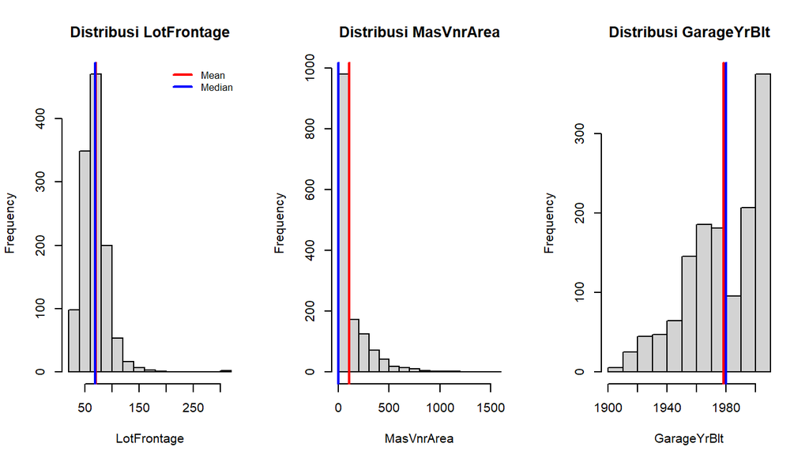

```r
# Cek distribusi variabel dengan missing value terbanyak sebelum memilih imputasi
par(mfrow = c(1, 3))

hist(df$LotFrontage, main = "Distribusi LotFrontage",
     xlab = "LotFrontage", col = "lightgray")
abline(v = mean(df$LotFrontage,   na.rm = TRUE), col = "red",  lwd = 2)
abline(v = median(df$LotFrontage, na.rm = TRUE), col = "blue", lwd = 2)
legend("topright", legend = c("Mean","Median"), col = c("red","blue"),
       lty = 1, lwd = 2, cex = 0.8, bty = "n")

hist(df$MasVnrArea, main = "Distribusi MasVnrArea",
     xlab = "MasVnrArea", col = "lightgray")
abline(v = mean(df$MasVnrArea,   na.rm = TRUE), col = "red",  lwd = 2)
abline(v = median(df$MasVnrArea, na.rm = TRUE), col = "blue", lwd = 2)

hist(df$GarageYrBlt, main = "Distribusi GarageYrBlt",
     xlab = "GarageYrBlt", col = "lightgray")
abline(v = mean(df$GarageYrBlt,   na.rm = TRUE), col = "red",  lwd = 2)
abline(v = median(df$GarageYrBlt, na.rm = TRUE), col = "blue", lwd = 2)
```

```r
par(mfrow = c(1, 1))
```

```r
# Isi missing value dengan median untuk semua variabel numerik yang perlu
var_imputasi <- c("LotFrontage", "GarageYrBlt", "GarageCars",
                  "GarageArea", "TotalBsmtSF", "BsmtFinSF1",
                  "BsmtFinSF2", "BsmtUnfSF", "MasVnrArea")

# Imputasi missing value dengan median
df$LotFrontage[is.na(df$LotFrontage)] <- median(df$LotFrontage, na.rm = TRUE)
df$GarageYrBlt[is.na(df$GarageYrBlt)] <- median(df$GarageYrBlt, na.rm = TRUE)
df$MasVnrArea[is.na(df$MasVnrArea)]   <- median(df$MasVnrArea, na.rm = TRUE)

# Cek apakah masih ada missing value
colSums(is.na(df))
```

```
##            Id    MSSubClass      MSZoning   LotFrontage       LotArea
##             0             0             0             0             0
##        Street         Alley      LotShape   LandContour     Utilities
##             0          1369             0             0             0
##     LotConfig     LandSlope  Neighborhood    Condition1    Condition2
##             0             0             0             0             0
##      BldgType    HouseStyle   OverallQual   OverallCond     YearBuilt
##             0             0             0             0             0
##  YearRemodAdd     RoofStyle      RoofMatl   Exterior1st   Exterior2nd
##             0             0             0             0             0
##    MasVnrType    MasVnrArea     ExterQual     ExterCond    Foundation
##             8             0             0             0             0
##      BsmtQual      BsmtCond  BsmtExposure  BsmtFinType1    BsmtFinSF1
##             0             0             0             0             0
##  BsmtFinType2    BsmtFinSF2     BsmtUnfSF   TotalBsmtSF       Heating
##             0             0             0             0             0
##     HeatingQC    CentralAir    Electrical     X1stFlrSF     X2ndFlrSF
##             0             0             1             0             0
##  LowQualFinSF     GrLivArea  BsmtFullBath  BsmtHalfBath      FullBath
##             0             0             0             0             0
##      HalfBath  BedroomAbvGr  KitchenAbvGr   KitchenQual  TotRmsAbvGrd
##             0             0             0             0             0
##    Functional    Fireplaces   FireplaceQu    GarageType   GarageYrBlt
##             0             0             0            81             0
##  GarageFinish    GarageCars    GarageArea    GarageQual    GarageCond
##             0             0             0             0             0
##    PavedDrive    WoodDeckSF   OpenPorchSF EnclosedPorch    X3SsnPorch
##             0             0             0             0             0
##   ScreenPorch      PoolArea        PoolQC         Fence   MiscFeature
##             0             0             0             0          1406
##       MiscVal        MoSold        YrSold      SaleType SaleCondition
##             0             0             0             0             0
##     SalePrice
##             0
```

```r
# Semua variabel ordinal dan numerik sudah tidak memiliki NA
```

Tersisa variabel Alley, GarageType, Electrical, MasVnrType, dan MiscFeature yang masih memiliki nilai NA. NA di variabel-variabel ini berarti tidak memiliki gang, tidak memiliki garasi, dan tidak memiliki fitur tambahan. Diperlukan pengisian NA sebagai ‘None’

```r
df$Alley[is.na(df$Alley)] <- "NoAlley"
df$MasVnrType[is.na(df$MasVnrType)] <- "None"
df$GarageType[is.na(df$GarageType)] <- "None"
df$MiscFeature[is.na(df$MiscFeature)]   <- "None"
df$Electrical[is.na(df$Electrical)] <- "FuseA" #pilih yang average

# Cek apakah masih ada missing value
colSums(is.na(df))
```

```
##            Id    MSSubClass      MSZoning   LotFrontage       LotArea
##             0             0             0             0             0
##        Street         Alley      LotShape   LandContour     Utilities
##             0             0             0             0             0
##     LotConfig     LandSlope  Neighborhood    Condition1    Condition2
##             0             0             0             0             0
##      BldgType    HouseStyle   OverallQual   OverallCond     YearBuilt
##             0             0             0             0             0
##  YearRemodAdd     RoofStyle      RoofMatl   Exterior1st   Exterior2nd
##             0             0             0             0             0
##    MasVnrType    MasVnrArea     ExterQual     ExterCond    Foundation
##             0             0             0             0             0
##      BsmtQual      BsmtCond  BsmtExposure  BsmtFinType1    BsmtFinSF1
##             0             0             0             0             0
##  BsmtFinType2    BsmtFinSF2     BsmtUnfSF   TotalBsmtSF       Heating
##             0             0             0             0             0
##     HeatingQC    CentralAir    Electrical     X1stFlrSF     X2ndFlrSF
##             0             0             0             0             0
##  LowQualFinSF     GrLivArea  BsmtFullBath  BsmtHalfBath      FullBath
##             0             0             0             0             0
##      HalfBath  BedroomAbvGr  KitchenAbvGr   KitchenQual  TotRmsAbvGrd
##             0             0             0             0             0
##    Functional    Fireplaces   FireplaceQu    GarageType   GarageYrBlt
##             0             0             0             0             0
##  GarageFinish    GarageCars    GarageArea    GarageQual    GarageCond
##             0             0             0             0             0
##    PavedDrive    WoodDeckSF   OpenPorchSF EnclosedPorch    X3SsnPorch
##             0             0             0             0             0
##   ScreenPorch      PoolArea        PoolQC         Fence   MiscFeature
##             0             0             0             0             0
##       MiscVal        MoSold        YrSold      SaleType SaleCondition
##             0             0             0             0             0
##     SalePrice
##             0
```

# Bagian 2: Seleksi Variabel dengan Uji Statistik

- Variabel numerik/ordinal : Korelasi Spearman untuk mengukur kekuatan hubungan dengan SalePrice
- Variabel kategorik nominal : Kruskal-Wallis + Epsilon-squared untuk menguji apakah median SalePrice berbeda antar kategori, dan seberapa besar efeknya secara praktis

## 2.1 Seleksi Variabel Numerik — Korelasi Spearman

Korelasi Pearson mengasumsikan distribusi normal, sedangkan `SalePrice` kita tidak normal (skewed). Korelasi Spearman berbasis ranking sehingga lebih cocok untuk data seperti ini. Nilai korelasi Spearman (rho) berkisar dari -1 sampai 1:

- rho >= 0.5: hubungan kuat
- 0.3 <= rho <= 0.5: hubungan sedang
- rho < 0.3: hubungan lemah

```r
# Hitung korelasi Spearman setiap variabel numerik terhadap SalePrice
cor_hasil <- c()
for (v in var_numerik_lengkap) {
  rho <- cor(df[[v]], df$SalePrice, method = "spearman")
  cor_hasil[v] <- rho
}

# Urutkan dari terbesar ke terkecil (nilai absolut)
cor_hasil <- sort(cor_hasil, decreasing = TRUE)

cor_df <- data.frame(
  Variabel = names(cor_hasil),
  Korelasi = round(cor_hasil, 3),
  Kekuatan = ifelse(abs(cor_hasil) >= 0.5, "Kuat",
             ifelse(abs(cor_hasil) >= 0.3, "Sedang", "Lemah"))
)
rownames(cor_df) <- NULL

print(cor_df)
```

```
##         Variabel Korelasi Kekuatan
## 1    OverallQual    0.810     Kuat
## 2      GrLivArea    0.731     Kuat
## 3     GarageCars    0.691     Kuat
## 4      ExterQual    0.684     Kuat
## 5       BsmtQual    0.678     Kuat
## 6    KitchenQual    0.673     Kuat
## 7      YearBuilt    0.653     Kuat
## 8     GarageArea    0.649     Kuat
## 9       FullBath    0.636     Kuat
## 10  GarageFinish    0.634     Kuat
## 11   TotalBsmtSF    0.603     Kuat
## 12     X1stFlrSF    0.575     Kuat
## 13  YearRemodAdd    0.571     Kuat
## 14   GarageYrBlt    0.563     Kuat
```

[output cut: 38 more lines]

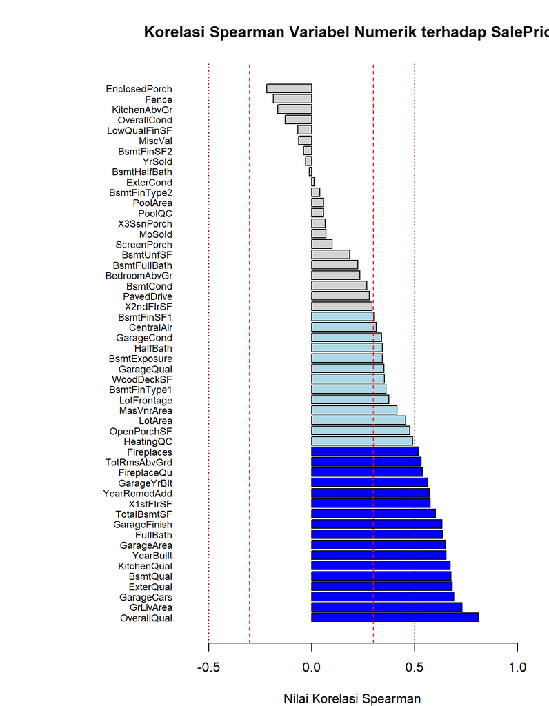

```r
#Visualisasi
par(mar = c(4, 12, 4, 2))
barplot(cor_hasil,
        horiz     = TRUE,
        las       = 1,
        col       = ifelse(abs(cor_hasil) >= 0.5, "blue",
                    ifelse(abs(cor_hasil) >= 0.3, "lightblue", "lightgray")),
        main      = "Korelasi Spearman Variabel Numerik terhadap SalePrice",
        xlab      = "Nilai Korelasi Spearman",
        cex.names = 0.75,
        xlim      = c(-0.6, 1))
abline(v = 0.3,  col = "red",    lty = 2)
abline(v = -0.3, col = "red",    lty = 2)
abline(v = 0.5,  col = "darkred", lty = 3)
abline(v = -0.5, col = "darkred", lty = 3)
```

Garis putus-putus merah menandai batas korelasi sedang (+- 0.3), dan garis titik merah tua menandai batas korelasi kuat (+- 0.5). Variabel di sebelah kanan atau kiri garis merah dianggap cukup bermakna untuk digunakan sebagai prediktor.

```r
# Pilih variabel dengan korelasi >= 0.5 (pilih hanya yang kuat)
var_num_terpilih <- names(cor_hasil[abs(cor_hasil) >= 0.5])
cat("Variabel numerik terpilih (|rho| >= 0.5):\n")
```

```
## Variabel numerik terpilih (|rho| >= 0.5):
```

```r
print(var_num_terpilih)
```

```
##  [1] "OverallQual"  "GrLivArea"    "GarageCars"   "ExterQual"    "BsmtQual"
##  [6] "KitchenQual"  "YearBuilt"    "GarageArea"   "FullBath"     "GarageFinish"
## [11] "TotalBsmtSF"  "X1stFlrSF"    "YearRemodAdd" "GarageYrBlt"  "FireplaceQu"
## [16] "TotRmsAbvGrd" "Fireplaces"
```

```r
cat("\nTotal:", length(var_num_terpilih), "variabel\n")
```

```
##
## Total: 17 variabel
```

## 2.2 Seleksi Variabel Kategorik — Kruskal-Wallis + Effect Size

Untuk variabel kategorik nominal, korelasi tidak bisa digunakan karena nilainya bukan angka berurutan. Kruskal-Wallis adalah versi non-parametrik dari ANOVA untuk menguji apakah distribusi SalePrice berbeda secara signifikan antar kelompok kategori.

- H0: semua grup memiliki distribusi harga yang sama
- Jika p-value < 0.05, tolak H0 maka variabel ini berpengaruh terhadap harga

Namun p-value saja tidak cukup — dengan 1.460 data, hampir semua variabel akan signifikan. Oleh karena itu kita juga hitung **Epsilon-squared (ε²)** sebagai ukuran *effect size*: seberapa besar pengaruh variabel tersebut secara **praktis**.

Interpretasi ε²: - ε² < 0.01 : efek kecil (tidak penting secara praktis) - ε² ≈ 0.08 : efek sedang - ε² ≥ 0.26 : efek besar

```r
# Hitung Kruskal-Wallis untuk semua variabel kategorik
var_kategorik_cek <- var_kategorik  # dari definisi sebelumnya
n <- nrow(df)
hasil_kw <- data.frame(Variabel = character(),
                       Pvalue = numeric(),
                       EpsilonSquared = numeric(),
                       stringsAsFactors = FALSE)

for (v in var_kategorik_cek) {
  # Buang NA jika ada (meskipun sudah diimputasi)
  data_clean <- df[!is.na(df[[v]]), ]
  kw_test <- kruskal.test(SalePrice ~ get(v), data = data_clean)
  k <- length(unique(data_clean[[v]]))
  eps2 <- (kw_test$statistic - k + 1) / (n - k)
  hasil_kw <- rbind(hasil_kw, data.frame(Variabel = v,
                                         Pvalue = kw_test$p.value,
                                         EpsilonSquared = eps2))
}
kw_df <- hasil_kw[order(hasil_kw$EpsilonSquared, decreasing = TRUE), ]
```

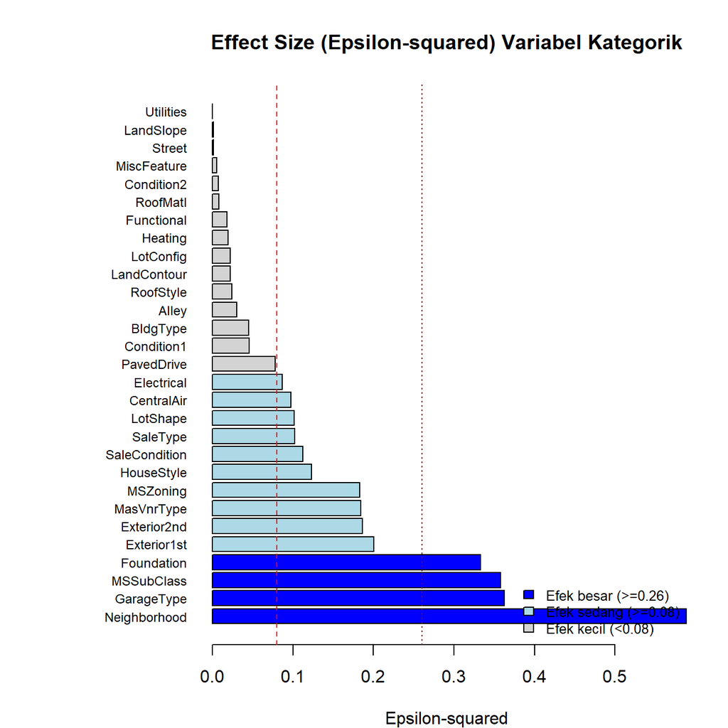

```r
# Visualisasi effect size tiap variabel kategorik
# mencari variabel signifikan (p<0.05) tapi efeknya kecil

par(mar = c(4, 10, 4, 2))
barplot(kw_df$EpsilonSquared,
        names.arg = kw_df$Variabel,
        horiz     = TRUE,
        las       = 1,
        col       = ifelse(kw_df$EpsilonSquared >= 0.26, "blue",
                    ifelse(kw_df$EpsilonSquared >= 0.08, "lightblue", "lightgray")),
        main      = "Effect Size (Epsilon-squared) Variabel Kategorik",
        xlab      = "Epsilon-squared",
        cex.names = 0.75)
abline(v = 0.08, col = "red",     lty = 2)
abline(v = 0.26, col = "darkred", lty = 3)
legend("bottomright",
       legend = c("Efek besar (>=0.26)", "Efek sedang (>=0.08)", "Efek kecil (<0.08)"),
       fill   = c("blue", "lightblue", "lightgray"),
       bty    = "n", cex = 0.8)
```

```r
par(mar = c(5, 4, 4, 2))
```

```r
# Pilih variabel kategorik yang:
# 1. Signifikan secara statistik (p < 0.05), DAN
# 2. Effect size cukup bermakna (epsilon2 >= 0.08 = sedang ke atas)
# Alasan: dengan n=1460, hampir semua variabel akan signifikan secara statistik.
# Effect size memastikan variabel yang dipilih benar-benar berpengaruh secara praktis.

var_kat_terpilih <- kw_df$Variabel[kw_df$Pvalue < 0.05 & kw_df$EpsilonSquared >= 0.08]
```

```
## Variabel kategorik terpilih (p < 0.05 DAN epsilon2 >= 0.08):
```

```
##  [1] "Neighborhood"  "GarageType"    "MSSubClass"    "Foundation"
##  [5] "Exterior1st"   "Exterior2nd"   "MasVnrType"    "MSZoning"
##  [9] "HouseStyle"    "SaleCondition" "SaleType"      "LotShape"
## [13] "CentralAir"    "Electrical"
```

```
##
## Total: 14 variabel
```

## 2.3 Ringkasan Variabel Terpilih untuk Eksplorasi

Dari seleksi statistik di atas, kita memilih variabel-variabel berikut untuk eksplorasi Pemilihan ini sepenuhnya berdasarkan bukti statistik (korelasi Spearman dan Kruskal-Wallis + Epsilon-squared)

```r
# Variabel numerik terpilih (rho >= 0.5 dengan SalePrice)
var_eksplorasi_num <- c("OverallQual", "GrLivArea", "TotalBsmtSF",
                        "GarageCars", "GarageArea", "ExterQual",
                        "KitchenQual", "BsmtQual", "YearBuilt", "FullBath")

# Variabel kategorik terpilih (p < 0.05 DAN epsilon2 >= 0.08)
# Ambil 4 teratas berdasarkan epsilon-squared
var_eksplorasi_kat <- head(var_kat_terpilih, 4)
```

```
## VARIABEL UNTUK EKSPLORASI
```

```
## Numerik/Ordinal:
```

```
##   OverallQual     rho = +0.810
##   GrLivArea       rho = +0.731
##   TotalBsmtSF     rho = +0.603
##   GarageCars      rho = +0.691
##   GarageArea      rho = +0.649
##   ExterQual       rho = +0.684
##   KitchenQual     rho = +0.673
##   BsmtQual        rho = +0.678
##   YearBuilt       rho = +0.653
##   FullBath        rho = +0.636
```

```
##
## Kategorik:
```

```
##   Neighborhood    epsilon2 = 0.589
##   GarageType      epsilon2 = 0.362
##   MSSubClass      epsilon2 = 0.358
##   Foundation      epsilon2 = 0.333
```

# Bagian 3: Eksplorasi Data Mendalam

Pada bagian ini kita menggali lebih dalam hubungan setiap variabel terpilih dengan SalePrice

## 3.1 Distribusi Harga Rumah (SalePrice)

Sebelum menganalisis faktor-faktornya, kita harus memahami distribusi variabel target.

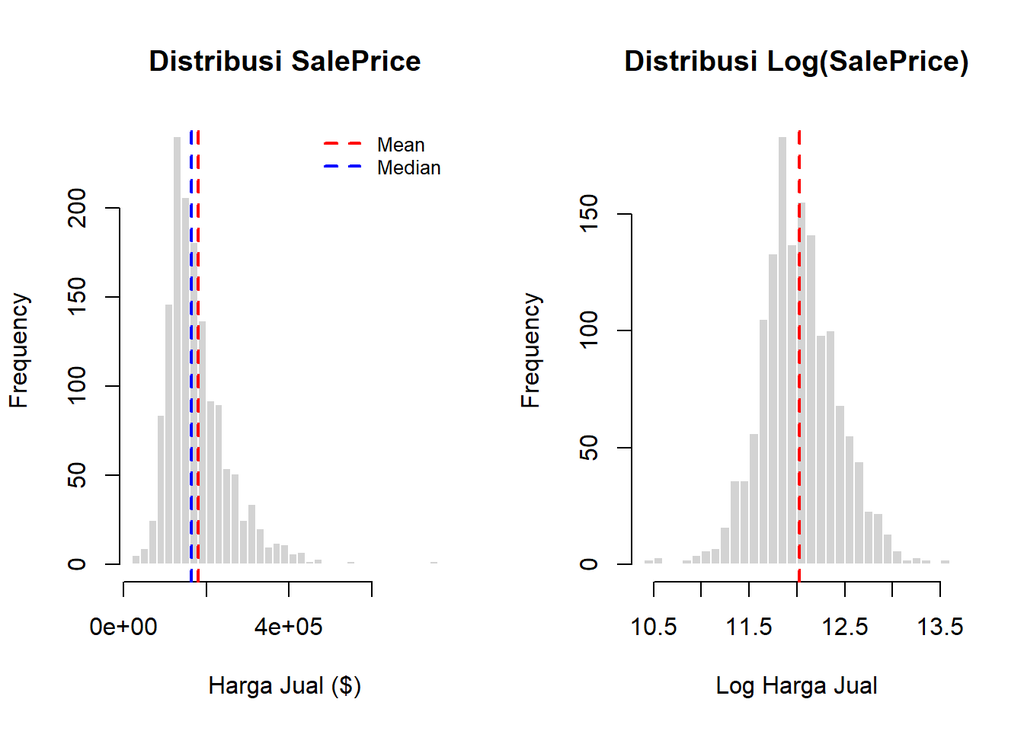

```r
par(mfrow = c(1, 2))

hist(df$SalePrice,
     main   = "Distribusi SalePrice",
     xlab   = "Harga Jual ($)",
     col    = "lightgray",
     breaks = 40,
     border = "white")
abline(v = mean(df$SalePrice),   col = "red",  lwd = 2, lty = 2)
abline(v = median(df$SalePrice), col = "blue", lwd = 2, lty = 2)
legend("topright", legend = c("Mean","Median"), col = c("red","blue"),
       lty = 2, lwd = 2, cex = 0.8, bty = "n")

hist(log(df$SalePrice),
     main   = "Distribusi Log(SalePrice)",
     xlab   = "Log Harga Jual",
     col    = "lightgray",
     breaks = 40,
     border = "white")
abline(v = mean(log(df$SalePrice)), col = "red", lwd = 2, lty = 2)
```

```r
par(mfrow = c(1, 1))
```

```r
#Statistik Deskriptif SalePrice
summary(df$SalePrice)
```

```
##    Min. 1st Qu.  Median    Mean 3rd Qu.    Max.
##   34900  129975  163000  180921  214000  755000
```

SalePrice berdistribusi **right-skewed** dimana Mean > Median menunjukkan ada rumah-rumah sangat mahal yang menarik rata-rata ke atas. Log-transformasi membuat distribusi lebih simetris, yang akan berguna saat pemodelan. Oleh karena itu kita menggunakan uji non-parametrik (Kruskal-Wallis, Spearman) karena asumsi normalitas tidak terpenuhi. Oleh karena itu dilakukan transformasi log(SalePrice) untuk membuat distribusi lebih simetris, mengurangi pengaruh outlier, dan meningkatkan performa model prediksi.

## 3.2 OverallQual (Kualitas Keseluruhan Rumah) — SalePrice

OverallQual menilai kualitas material dan finishing rumah pada skala 1 (Very Poor) hingga 10 (Very Excellent). Variabel ini memiliki korelasi Spearman tertinggi dari seluruh variabel numerik.

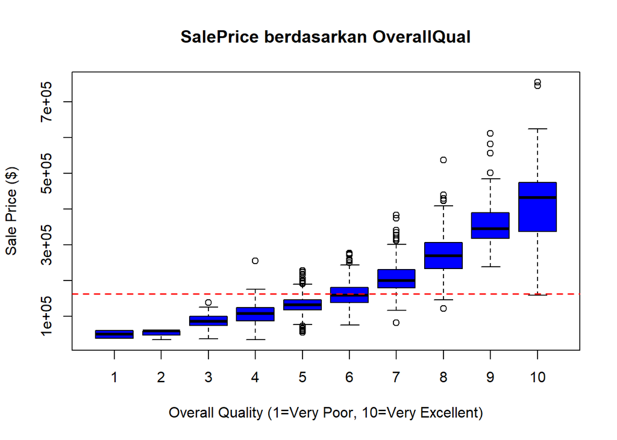

```r
# Boxplot: distribusi harga untuk tiap nilai kualitas
# digunakan boxplot karena OverallQual adalah diskrit (1-10)
boxplot(SalePrice ~ OverallQual, data = df,
        main   = "SalePrice berdasarkan OverallQual",
        xlab   = "Overall Quality (1=Very Poor, 10=Very Excellent)",
        ylab   = "Sale Price ($)",
        col    = "blue")

#garis untuk memperjelas posisi nilai median
abline(h = median(df$SalePrice), col = "red", lty = 2, lwd = 1.5)
```

```r
kw_oq  <- kruskal.test(SalePrice ~ OverallQual, data = df)
k_oq   <- length(unique(df$OverallQual))
eps2_oq <- (kw_oq$statistic - k_oq + 1) / (nrow(df) - k_oq)
```

```
## Kruskal-Wallis Test - OverallQual vs SalePrice:
```

```
##   p-value     : 3.506973e-202
```

```
##   Kesimpulan  : Signifikan (tolak H0)
```

```
##   Epsilon-squared : 0.66 (0.01=kecil, 0.08 =sedang, 0.26=besar)
```

**Kesimpulan** Uji Kruskal-Wallis menunjukkan bahwa terdapat perbedaan harga jual yang sangat signifikan antar tingkat kualitas bangunan (H = 966,1; df = 9; p < 0,005), dengan effect size epsilon-squared sebesar 0,66 yang menunjukan bahwa OverallQual memiliki pengaruh praktis yang sangat besar terhadap SalePrice. Terbukti melalui boxplot yang memperlihatkan kenaikan harga yang konsisten dan monoton seiring meningkatnya skor kualitas atau dengan kata lain semakin tinggi kualitas maka semakin tinggi harga ruma. Hal ini menjadikan OverallQual sebagai salah satu prediktor terkuat dalam dataset ini.

Visualisasi menggunakan boxplot karena OverallQual bersifat diskrit (nilai 1-10). Dnegan boxplot distribusi harga di setiap level kualitas akan ditampilkan. Garis merah putus putus ditambahkan sebagai refrensi median keseluruhan dataset, sehingga mudah melihat grup mana yang beda di atas/bawah rata-rata pasar.

## 3.3 GrLivArea (Luas Area Tinggal) — SalePrice

GrLivArea` adalah luas area tinggal di atas tanah dalam satuan sqft. Hubungannya dengan harga dieksplorasi menggunakan scatter plot dan regresi linear sederhana.

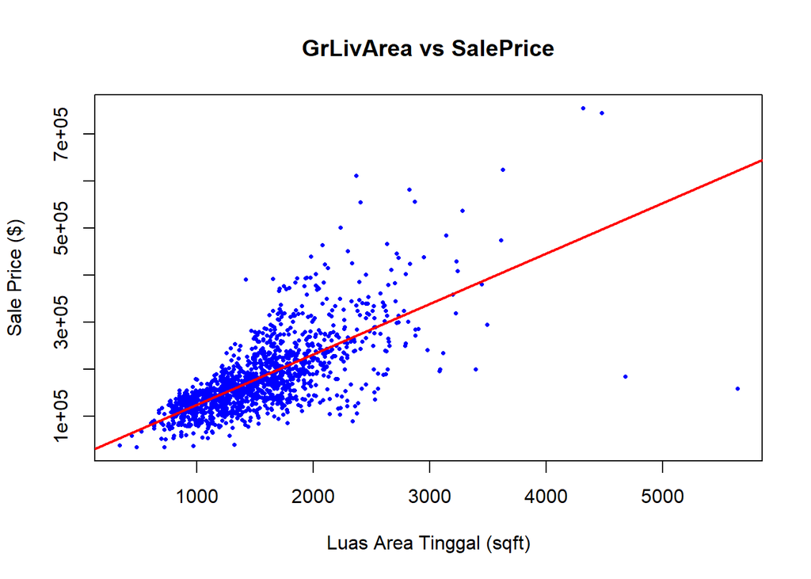

```r
# Scatter plot + garis regresi
# Alasan scatter plot: GrLivArea adalah variabel kontinu, sehingga scatter plot
# lebih tepat untuk melihat hubungan antar dua variabel kontinu
plot(df$GrLivArea, df$SalePrice,
     main = "GrLivArea vs SalePrice",
     xlab = "Luas Area Tinggal (sqft)",
     ylab = "Sale Price ($)",
     col  = "blue",
     pch  = 16, cex = 0.5)
abline(lm(SalePrice ~ GrLivArea, data = df), col = "red", lwd = 2)
```

```r
model_slr <- lm(SalePrice ~ GrLivArea, data = df)
model_slr
```

```
##
## Call:
## lm(formula = SalePrice ~ GrLivArea, data = df)
##
## Coefficients:
## (Intercept)    GrLivArea
##     18569.0        107.1
```

```r
summary(model_slr)
```

```
##
## Call:
## lm(formula = SalePrice ~ GrLivArea, data = df)
##
## Residuals:
##     Min      1Q  Median      3Q     Max
## -462999  -29800   -1124   21957  339832
##
## Coefficients:
##              Estimate Std. Error t value Pr(>|t|)
## (Intercept) 18569.026   4480.755   4.144 3.61e-05 ***
## GrLivArea     107.130      2.794  38.348  < 2e-16 ***
## ---
## Signif. codes:  0 '***' 0.001 '**' 0.01 '*' 0.05 '.' 0.1 ' ' 1
##
## Residual standard error: 56070 on 1458 degrees of freedom
## Multiple R-squared:  0.5021, Adjusted R-squared:  0.5018
## F-statistic:  1471 on 1 and 1458 DF,  p-value: < 2.2e-16
```

**Kesimpulan** GrLivArea memiliki korelasi Spearman sebesar 0,731 dengan SalePrice, ada hubungan positif yang kuat antara luas area tinggal dan harga, artinya semakin luas area tinggal, semakin tinggi harga jual. Dengan R^2 sebesar 0,50 yang berarti luas area tinggal saja mampu menjelaskan setengah dari variasi harga, namun adanya outlier dan sisa variasi yang belum terjelaskan mengindikasikan bahwa prediktor lain tetap dibutuhkan untuk membangun model yang lebih akurat. Visualisasi menggunakan scatter plot karena GrLivArea adalah variabel kontinu (bukan diskrit), scatter plot dipilih untuk memvisualisasikan hubungan antara dua variabel kontinu secara langsung. Setiap titik mewakili satu rumah, dan pola sebarannya langsung terlihat. Garis merah adalah garis regresi linear sederhana yang menunjukkan tren umum hubungan antara luas dan harga. Berdasarkan visualisasi terlihat beberapa outlier rumah yang sangat luas tapi harganya tidak proporsional, kemungkinan karena kualitas rendah atau kondisi khusus. `GrLivArea` saja menjelaskan sebagian variasi harga, sehingga dibutuhkan prediktor lain dalam model yang lebih lengkap.

Temuan dari eksplorasi menunjukkan bahwa GrLivArea saja hanya mampu menjelaskan 50% variasi harga (R² = 0,50), sementara analisis seleksi variabel di Bagian 2 telah mengidentifikasi 16 prediktor lain yang memiliki korelasi kuat dengan SalePrice. Oleh karena itu, Bagian 4 membangun model regresi berganda yang menggabungkan seluruh variabel terpilih termasuk OverallQual, kualitas ruangan, luas basement, dan tahun dibangun, untuk mengatasi keterbatasan model tunggal tersebut dan menghasilkan prediksi yang lebih akurat dan komprehensif.

## 3.4 Neighborhood (Lokasi) — SalePrice

Neighborhood adalah lokasi fisik rumah di dalam kota. Lokasi adalah salah satu faktor terpenting dalam harga properti.

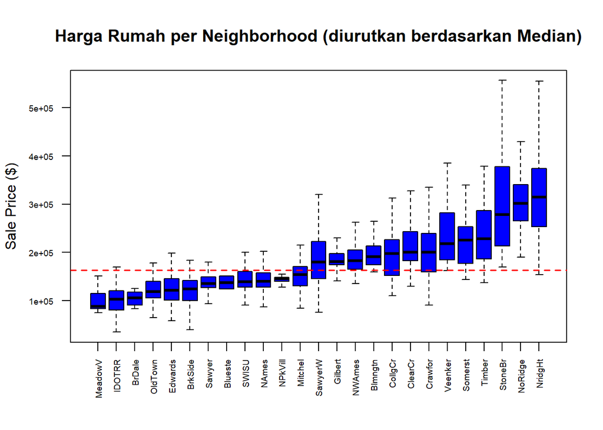

```r
med_neigh   <- tapply(df$SalePrice, df$Neighborhood, median)
neigh_order <- names(sort(med_neigh))
df$Neighborhood_f <- factor(df$Neighborhood, levels = neigh_order)

boxplot(SalePrice ~ Neighborhood_f, data = df,
        las      = 2,
        col      = "blue",
        main     = "Harga Rumah per Neighborhood (diurutkan berdasarkan Median)",
        xlab     = "",
        ylab     = "Sale Price ($)",
        cex.axis = 0.6,
        outline  = FALSE)
abline(h = median(df$SalePrice), col = "red", lty = 2, lwd = 1.5)
```

```r
kw_oq  <- kruskal.test(SalePrice ~ Neighborhood, data = df)
k_oq   <- length(unique(df$Neighborhood))
eps2_oq <- (kw_oq$statistic - k_oq + 1) / (nrow(df) - k_oq)
```

```
## Kruskal-Wallis Test - Neighborhood vs SalePrice:
```

```
##   p-value     : 6.696799e-168
```

```
##   Kesimpulan  : Signifikan (tolak H0)
```

```
##   Epsilon-squared : 0.589 (0.01=kecil, 0.08 =sedang, 0.26=besar)
```

**Kesimpulan** Boxplot menunjukkan bahwa Neighborhood (lokasi rumah) memiliki pengaruh yang kuat terhadap harga rumah. Setiap kawasan memiliki median harga yang berbeda, sehingga lokasi menjadi salah satu faktor penting dalam menentukan nilai properti. Perbedaan sebaran harga antar neighborhood juga menunjukkan bahwa ada kawasan dengan harga yang relatif seragam dan ada yang lebih bervariasi, sehingga variabel Neighborhood perlu dimasukkan dalam model prediksi agar hasilnya lebih akurat.

## 3.5 ExterQual (Kualitas material exterior rumah) — SalePrice

ExterQual menilai kualitas material dari exterior rumah dari skala Excellent (Ex), Goog (Gd), Average (TA), Fair (FA), sampai Poor (Po). Variabel ini memiliki korelasi Spearman tertinggi keempat dari seluruh variabel numerik.

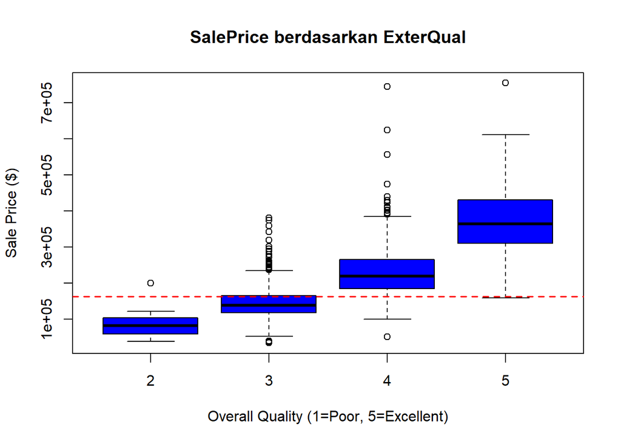

```r
# Boxplot: distribusi harga untuk tiap nilai kualitas
# Menggunakan boxplot karena ExterQuall adalah data ordinal yang akan dibandingkna dengan variabel Sale Price yang merupakan numerik
# sehingga boxplot per grup lebih informatif daripada scatter plot
boxplot(SalePrice ~ ExterQual, data = df,
        main   = "SalePrice berdasarkan ExterQual",
        xlab   = "Overall Quality (1=Poor, 5=Excellent)",
        ylab   = "Sale Price ($)",
        col    = "blue")

#garis untuk memperjelas posisi nilai median
abline(h = median(df$SalePrice), col = "red", lty = 2, lwd = 1.5)
```

Terdapat banyak outlier pada kategori Average dan Good

```r
kw_oq  <- kruskal.test(SalePrice ~ ExterQual, data = df)
k_oq   <- length(unique(df$ExterQual))
eps2_oq <- (kw_oq$statistic - k_oq + 1) / (nrow(df) - k_oq)

kw_oq
```

```
##
##  Kruskal-Wallis rank sum test
##
## data:  SalePrice by ExterQual
## Kruskal-Wallis chi-squared = 683.44, df = 3, p-value < 2.2e-16
```

```r
k_oq
```

```
## [1] 4
```

```r
eps2_oq
```

```
## Kruskal-Wallis chi-squared
##                  0.4673352
```

**Kesimpulan** Hasil Kruskal-Wallis menunjukkan p-value sangat kecil, artinya perbedaan harga antar tingkat kualitas eksterior rumah sangat signifikan. Rho yang bernilai +0.684 mengkonfirmasi bahwa perbedaan ini juga bermakna secara praktis — bukan hanya efek dari ukuran sampel besar.Boxplot menunjukkan pola jelas yaitu semakin tinggi kualitas, semakin tinggi harga rumah.Namun, terlihat beberapa outlier di grup rumah dengan ExterQuall Good dan Average yang artinya ada beberapa rumah yang harganya jauh lebih tinggi dibandingkna rumah lain dengan kualitas eksterior yang sama.

## 3.6 YearBuilt (Tahun rumah dibangun) — SalePrice

YearBuilt merupakan variabel yang menampilkan kapan tahun rumah dibangun. YearBuilt berupa data numerik. Variabel ini memiliki korelasi Spearman tertinggi ketujuh dari seluruh variabel numerik.

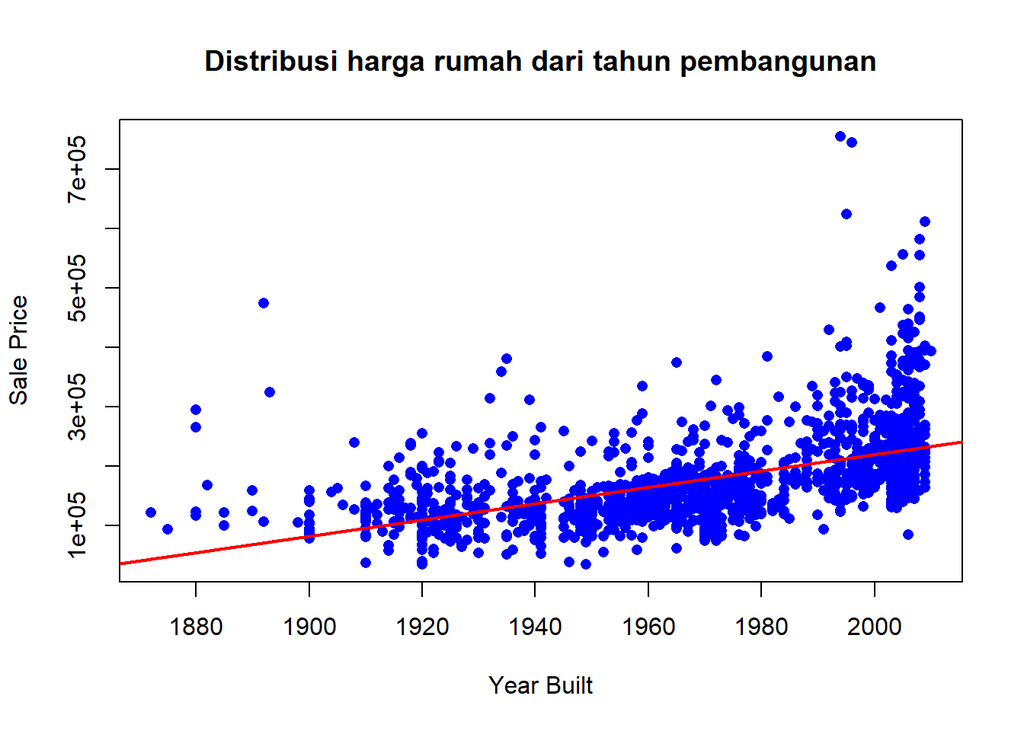

```r
# Scatterplot : distribusi harga rumah untuk tiap tahun rumah dibangun
# Menggunakan Scatterplot karena YearBuilt adalah variabel numerik yang dibandingkan dengan variabel Sale Price yang merupakan numerik juga
plot(df$YearBuilt, df$SalePrice,
     main = "Distribusi harga rumah dari tahun pembangunan",
     xlab = "Year Built",
     ylab = "Sale Price",
     pch = 16,
     col = "blue"
     )

#garis untuk memperjelas posisi nilai median
abline(lm(SalePrice ~ YearBuilt, data=df),
      col="red", lwd=2)
```

Dari scatterplot, YearBuilt tidak berdistribusi normal dan terbanyak outlier

```r
cor.test(df$YearBuilt, df$SalePrice, method = "spearman")
```

```
##
##  Spearman's rank correlation rho
##
## data:  df$YearBuilt and df$SalePrice
## S = 180150293, p-value < 2.2e-16
## alternative hypothesis: true rho is not equal to 0
## sample estimates:
##       rho
## 0.6526815
```

**Kesimpulan** Dari hasil uji diatas, di dapat nilai p-value sangat kecil sehingga dapat disimpulkan bahwa variabel YearBuilt dengan variabel SalePrice memiliki hubungan yang signifikan. Dari effect size, nilai rhonya 0.6526815 dimana berarti terdapat hubungan yang kuat antara tahun dibangun dengan harga rumah.

## 3.7 garageArea - garageCars

Untuk menganalisis hubungan antara GarageCars dan GarageArea, digunakan uji Kruskal-Wallis karena variabel GarageCars merupakan variabel kategorikal ordinal, sedangkan GarageArea merupakan variabel numerik yang tidak memenuhi distribusi normal. Uji Kruskal-Wallis merupakan alternatif non-parametrik yang digunakan untuk menguji apakah terdapat perbedaan distribusi atau median luas garasi pada masing-masing kategori kapasitas mobil garasi. Selain itu, visualisasi boxplot digunakan untuk melihat pola distribusi data dan perbedaan antar kelompok.

Hipotesis yang digunakan adalah: H0: Distribusi GarageArea sama pada seluruh kategori GarageCars. H1: Terdapat setidaknya satu kategori GarageCars yang memiliki distribusi GarageArea berbeda.

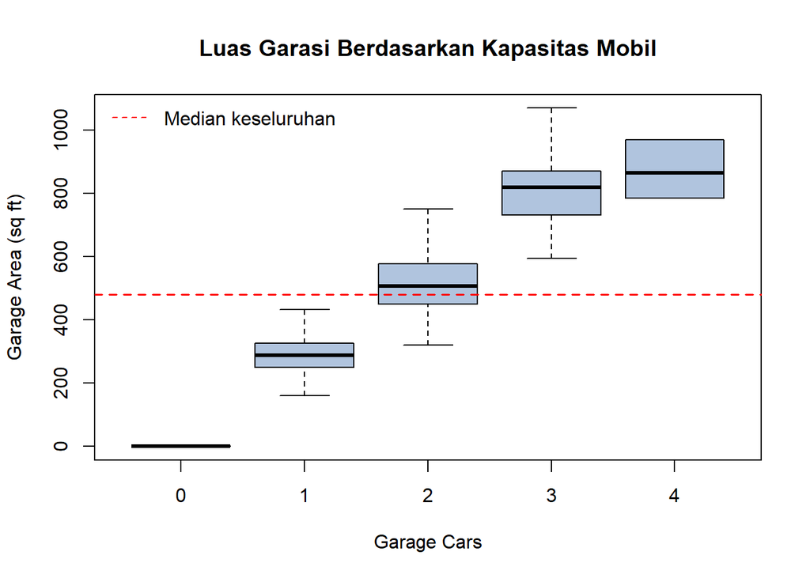

```r
# Scatter plot
boxplot(GarageArea ~ factor(GarageCars),
        data = df,
        col = "lightsteelblue",
        main = "Luas Garasi Berdasarkan Kapasitas Mobil",
        xlab = "Garage Cars",
        ylab = "Garage Area (sq ft)",
        outline = FALSE)

abline(h = median(df$GarageArea),
       col = "red",
       lty = 2,
       lwd = 1.5)

legend("topleft",
       legend = "Median keseluruhan",
       col = "red",
       lty = 2,
       bty = "n")
```

```r
kw <- kruskal.test(GarageArea ~ factor(GarageCars),
                   data = df)

H <- as.numeric(kw$statistic)
n <- nrow(df)
k <- length(unique(df$GarageCars))

kw
```

```
##
##  Kruskal-Wallis rank sum test
##
## data:  GarageArea by factor(GarageCars)
## Kruskal-Wallis chi-squared = 1063.7, df = 4, p-value < 2.2e-16
```

```r
epsilon_sq <- (H - k + 1) / (n - k)

epsilon_sq
```

```
## [1] 0.7283087
```

```r
cor(df$GarageCars,
    df$GarageArea,
    method = "spearman")
```

```
## [1] 0.8533174
```

Hasil uji Kruskal-Wallis menunjukkan nilai statistik χ² = 1063.7 dengan p-value < 0.05, sehingga H0 ditolak. Dengan demikian dapat disimpulkan bahwa terdapat perbedaan luas garasi yang signifikan antar kategori GarageCars.

Setelah diketahui bahwa perbedaan tersebut signifikan, dilakukan perhitungan effect size menggunakan Epsilon-Squared (ε²) untuk mengukur besarnya pengaruh GarageCars terhadap GarageArea. Penggunaan ukuran effect size diperlukan karena nilai p-value hanya menunjukkan adanya perbedaan yang signifikan secara statistik, tetapi tidak menunjukkan seberapa besar pengaruhnya. Berdasarkan perhitungan diperoleh nilai ε² = 0.7283 menunjukkan ukuran efek yang sangat besar, sehingga perbedaan GarageArea antar kategori GarageCars memiliki kekuatan pengaruh yang sangat kuat.

Selain itu, dilakukan analisis korelasi Spearman karena GarageCars memiliki sifat ordinal dan GarageArea tidak berdistribusi normal. Hasil korelasi Spearman sebesar ρ = 0.8533 menunjukkan hubungan positif yang sangat kuat antara kapasitas mobil garasi dan luas garasi. Hal ini mengindikasikan bahwa semakin besar kapasitas mobil yang dapat ditampung dalam garasi, maka semakin besar pula luas garasi yang dimiliki rumah.

Secara keseluruhan, hasil boxplot, uji Kruskal-Wallis, nilai Epsilon-Squared, dan korelasi Spearman menunjukkan bahwa GarageCars memiliki hubungan yang sangat kuat dan pengaruh yang sangat besar terhadap GarageArea. Hubungan yang sangat kuat ini mengindikasikan bahwa kedua variabel mengandung informasi yang serupa, sehingga dalam pemodelan prediksi harga rumah dapat dipertimbangkan penggunaan salah satu variabel untuk mengurangi redundansi informasi dan potensi multikolinearitas.

## 3.8 MSSubClass - SalesPrice

Untuk menganalisis pengaruh tipe rumah (MSSubClass) terhadap harga jual rumah (SalePrice), digunakan uji Kruskal-Wallis karena MSSubClass merupakan variabel kategorikal yang terdiri dari beberapa tipe rumah, sedangkan SalePrice merupakan variabel numerik yang tidak memenuhi asumsi normalitas. Uji ini digunakan untuk mengetahui apakah terdapat perbedaan distribusi harga rumah pada masing-masing tipe rumah.

Hipotesis : H0: Distribusi SalePrice sama pada semua kategori MSSubClass H1: Terdapat setidaknya satu kategori MSSubClass yang memiliki distribusi SalePrice berbeda

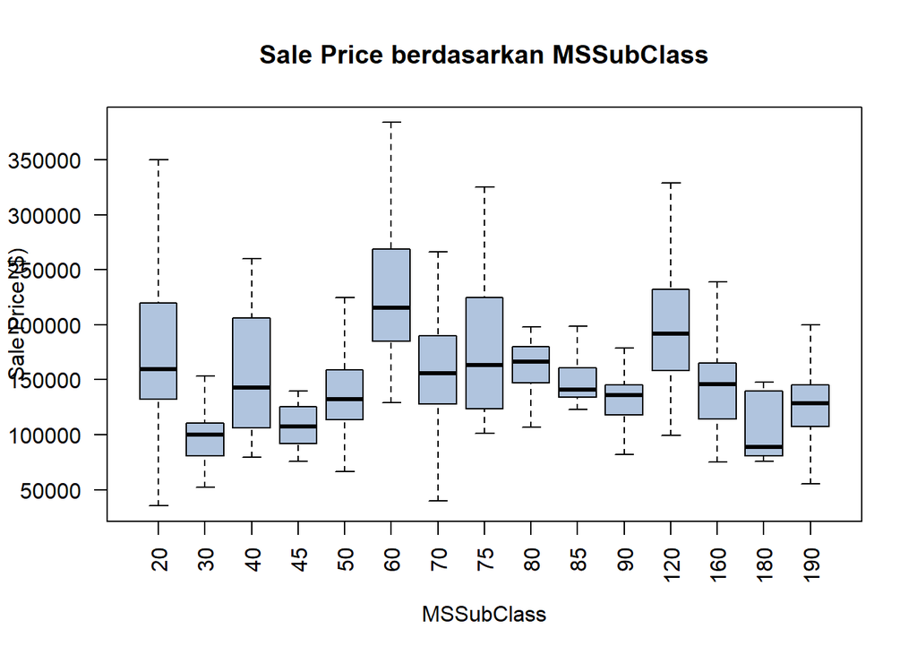

```r
boxplot(SalePrice ~ factor(MSSubClass),
        data = df,
        las = 2,
        col = "lightsteelblue",
        main = "Sale Price berdasarkan MSSubClass",
        xlab = "MSSubClass",
        ylab = "Sale Price ($)",
        outline = FALSE)
```

```r
kruskal_MSSub <- kruskal.test(SalePrice ~ factor(MSSubClass),
             data = df)

HMSsub <- as.numeric(kruskal_MSSub$statistic)
nMSsub <- nrow(df)
kMSsub <- length(unique(df$MSSubClass))

epsilon_sq_MSsub <- (HMSsub - kMSsub + 1) / (nMSsub - kMSsub)

kruskal_MSSub
```

```
##
##  Kruskal-Wallis rank sum test
##
## data:  SalePrice by factor(MSSubClass)
## Kruskal-Wallis chi-squared = 531.54, df = 14, p-value < 2.2e-16
```

```r
epsilon_sq_MSsub
```

```
## [1] 0.3581562
```

Berdasarkan visualisasi boxplot terlihat bahwa terdapat perbedaan median dan distribusi harga rumah antar kategori MSSubClass. Beberapa kategori seperti MSSubClass 60 dan 120 cenderung memiliki harga yang lebih tinggi dibandingkan kategori lainnya, sedangkan kategori 30 dan 45 memiliki harga yang relatif lebih rendah.

Hasil uji Kruskal-Wallis menunjukkan nilai χ²(14) = 531.54 dengan p-value < 0.05, sehingga H0 ditolak. Dengan demikian dapat disimpulkan bahwa terdapat perbedaan harga rumah yang signifikan antar kategori MSSubClass.

Untuk mengukur besarnya pengaruh, dilakukan perhitungan Epsilon-Squared (ε²) dan diperoleh nilai ε² = 0.3582. Nilai ini menunjukkan bahwa pengaruh MSSubClass terhadap SalePrice tergolong besar. Oleh karena itu, tipe rumah merupakan salah satu faktor yang berperan penting dalam menentukan harga jual rumah dan layak dipertimbangkan sebagai variabel prediktor dalam model prediksi harga rumah.

## 3.9 Foundation (Fondasi) — SalePrice

Untuk menganalisis pengaruh jenis fondasi (Foundation) terhadap harga jual rumah (SalePrice), digunakan uji Kruskal-Wallis karena Foundation merupakan variabel kategorikal yang terdiri dari beberapa kelompok, sedangkan SalePrice merupakan variabel numerik yang tidak memenuhi asumsi normalitas.

H0:Distribusi (median) SalePrice sama untuk semua kategori Foundation. H1: Terdapat setidaknya satu kategori Foundation yang memiliki distribusi (median) SalePrice berbeda.

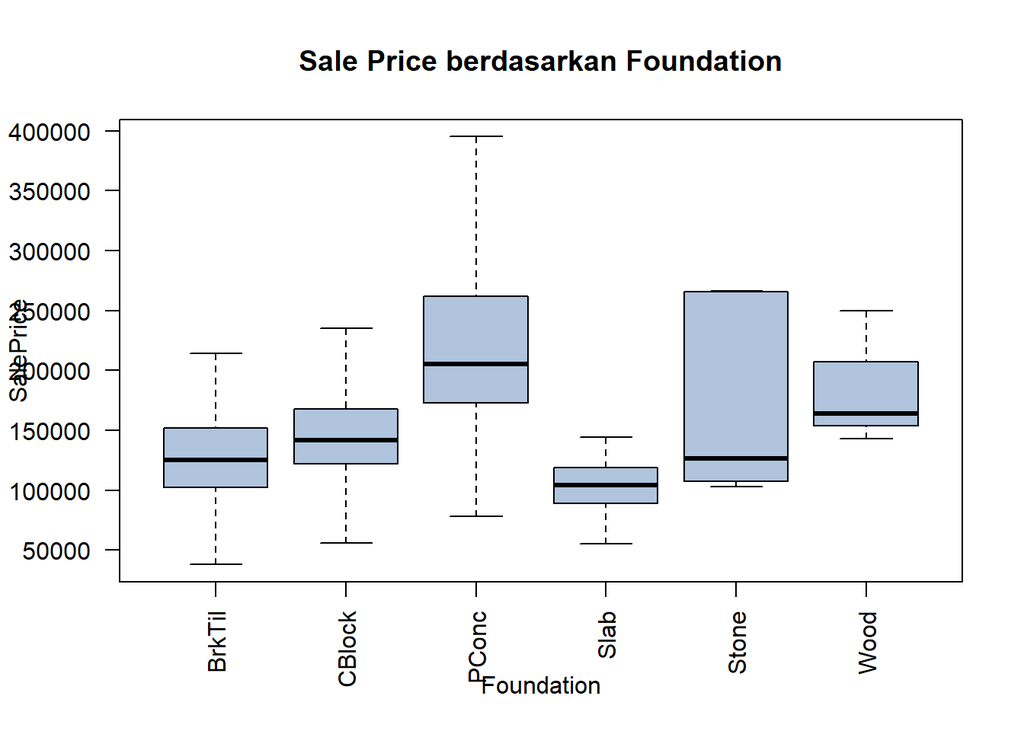

```r
boxplot(SalePrice ~ factor(Foundation),
        data = df,
        las = 2,
        col = "lightsteelblue",
        main = "Sale Price berdasarkan Foundation",
        xlab = "Foundation",
        ylab = "SalePrice",
        outline = FALSE)
```

```r
kruskal_Found <- kruskal.test(SalePrice ~ factor(Foundation),
             data = df)

HFound <- as.numeric(kruskal_Found$statistic)
nFound <- nrow(df)
kFound <- length(unique(df$Foundation))

epsilon_sq_found <- (HFound - kFound + 1) / (nFound - kFound)

kruskal_Found
```

```
##
##  Kruskal-Wallis rank sum test
##
## data:  SalePrice by factor(Foundation)
## Kruskal-Wallis chi-squared = 488.72, df = 5, p-value < 2.2e-16
```

```r
epsilon_sq_found
```

```
## [1] 0.3326841
```

Hasil uji Kruskal-Wallis menunjukkan nilai χ²(5) = 488.72 dengan p-value < 0.05, sehingga H0 ditolak. Dengan demikian dapat disimpulkan bahwa terdapat perbedaan harga rumah yang signifikan antar jenis fondasi.

Untuk mengukur besarnya pengaruh, dilakukan perhitungan Epsilon-Squared (ε²) dan diperoleh nilai ε² = 0.3327, yang menunjukkan bahwa pengaruh Foundation terhadap SalePrice tergolong besar. Oleh karena itu, jenis fondasi dapat dianggap sebagai salah satu faktor penting yang mempengaruhi harga jual rumah dan layak dipertimbangkan dalam pembangunan model prediksi harga rumah.

## 3.10 GarageType (Lokasi garasi berada) — SalePrice

`GarageType` adalah variabel yang menyimpan dimana garasi berada pada suatu rumah. Terdapat kategori : 2Types - lebih dari 1 tipe garasi di rumah Attchd - menyatu dengan rumah Basment - garasi berada d basement BuiltIn - garasi merupakan bagia dari rumah CarPort - ada car port (bukan garasi tertutup) Detchd - terpisah dari rumah None - tidak ada garasi

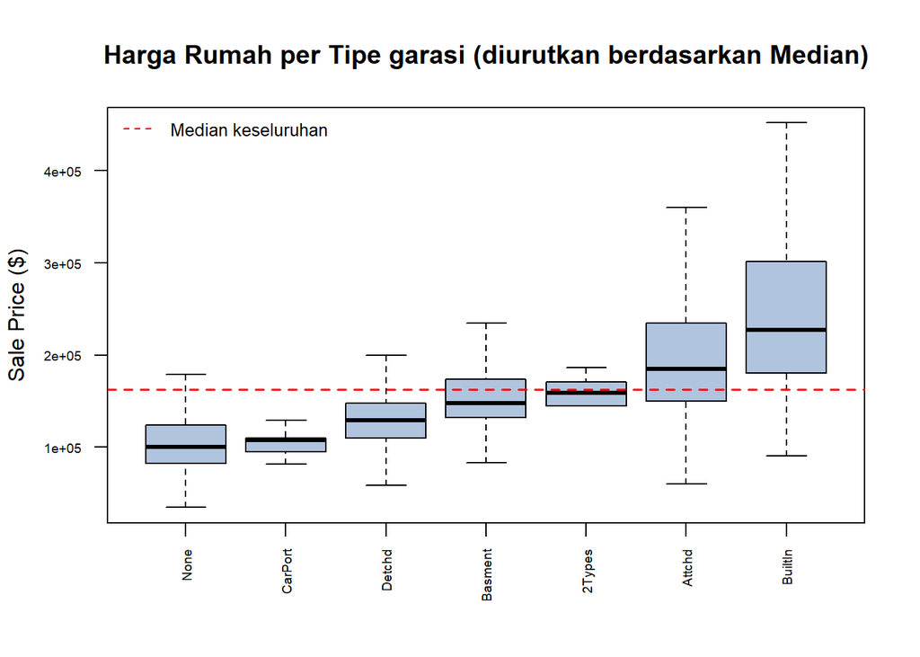

```r
med_garageType   <- tapply(df$SalePrice, df$GarageType, median)
garageType_order <- names(sort(med_garageType))
df$GarageType_f <- factor(df$GarageType, levels = garageType_order)

boxplot(SalePrice ~ GarageType_f, data = df,
        las      = 2,
        col      = "lightsteelblue",
        main     = "Harga Rumah per Tipe garasi (diurutkan berdasarkan Median)",
        xlab     = "",
        ylab     = "Sale Price ($)",
        cex.axis = 0.6,
        outline  = FALSE)
abline(h = median(df$SalePrice), col = "red", lty = 2, lwd = 1.5)
legend("topleft", legend = "Median keseluruhan", col = "red", lty = 2, bty = "n", cex = 0.8)
```

```r
kw_gt  <- kruskal.test(SalePrice ~ GarageType, data = df)
k_gt   <- length(unique(df$GarageType))
eps2_gt <- (kw_gt$statistic - k_gt + 1) / (nrow(df) - k_gt)
```

```
## Kruskal-Wallis Test - GarageType vs SalePrice:
```

```
##   p-value     : 7.581344e-112
```

```
##   Kesimpulan  : Signifikan (tolak H0)
```

```
##   Epsilon-squared : 0.362 (0.01=kecil, 0.08 =sedang, 0.26=besar)
```

Hasil uji Kruskal-Wallis menunjakan p-value sangat kecil yaitu < 0.05 yang menunjukan bahwa h0 ditolak dan disimpulkan perbedaan tipe garasi mempengaruhi harga rumah secara signifikan. Epsilon squared sebagai effect size juga menunjukkan bahwa perbedaan tipe garasi cukup kuat untuk mempengaruhi harga rumah.

# Bagian 4: Pemodelan Prediksi

Pada bagian ini dibuat beberapa model prediksi SalePrice menggunakan variabel-variabel yang sudah terpilih dari eksplorasi di Bagian 2 dan 3. Tujuannya adalah membandingkan beberapa model dan memilih yang terbaik.

## 4.1 Persiapan Data Model

Berdasarkan hasil eksplorasi di Bagian 3, ditemukan bahwa **GarageCars dan GarageArea sangat berkorelasi satu sama lain secara makna** dengan (ρ = 0.853, ε² = 0.728). Menggunakan kedua variabel sekaligus berisiko menyebabkan multikolinearitas yang membuat koefisien model tidak stabil (sesuai materi Collinearity). Oleh karena itu, **GarageArea dikeluarkan** dan hanya GarageCars yang dipertahankan karena memiliki korelasi sedikit lebih tinggi dengan SalePrice (rho = 0.691 vs 0.649).

Selain itu, variabel kategorik **MSSubClass dan Foundation** dimasukkan ke model berdasarkan hasil eksplorasi Bagian 3.8 dan 3.9 yang menunjukkan keduanya memiliki effect size besar (ε² = 0.358 dan ε² = 0.333).

```r
# Siapkan dataframe untuk pemodelan
# GarageArea dikeluarkan karena sangat berkorelasi dengan GarageCars (rho=0.853)
# MSSubClass dan Foundation dimasukkan karena terbukti berpengaruh besar di eksplorasi
df_model <- data.frame(
  SalePrice     = df$SalePrice,
  log_SalePrice = log(df$SalePrice),  # log SalePrice untuk model transformasi
  OverallQual   = df$OverallQual,
  GrLivArea     = df$GrLivArea,
  TotalBsmtSF   = df$TotalBsmtSF,
  YearBuilt     = df$YearBuilt,
  GarageCars    = df$GarageCars,      # dipilih, GarageArea dikeluarkan
  ExterQual     = df$ExterQual,
  KitchenQual   = df$KitchenQual,
  BsmtQual      = df$BsmtQual,
  FullBath      = df$FullBath,
  Fireplaces    = df$Fireplaces,
  CentralAir    = df$CentralAir,
  MSSubClass    = df$MSSubClass,      # variabel kategorik dari eksplorasi 3.8
  Foundation    = df$Foundation,       # variabel kategorik dari eksplorasi 3.9
  Neighborhood  = df$Neighborhood,
  GarageType    = df$GarageType
)
```

```
## Dimensi data model: 1460 baris, 17 kolom
```

```
## Variabel prediktor yang digunakan:
```

```
##  [1] "OverallQual"  "GrLivArea"    "TotalBsmtSF"  "YearBuilt"    "GarageCars"
##  [6] "ExterQual"    "KitchenQual"  "BsmtQual"     "FullBath"     "Fireplaces"
## [11] "CentralAir"   "MSSubClass"   "Foundation"   "Neighborhood" "GarageType"
```

## 4.2 Train-Test Split

Data dibagi menjadi **data latih (train) 80%** dan **data uji (test) 20%**. Model dibangun hanya dari data latih, lalu dievaluasi pada data test yang belum pernah dilihat model untuk menghindari overfitting.

```r
set.seed(42)  # agar hasil bisa direproduksi oleh siapapun

n <- nrow(df_model)
idx_train <- sample(1:n, size = floor(0.8 * n))  # ambil 80% indeks secara acak

train <- df_model[ idx_train, ]   # data latih
test  <- df_model[-idx_train, ]   # data uji (sisanya)
```

```
## Jumlah data train: 1168
```

```
## Jumlah data test : 292
```

## 4.3 Fungsi Evaluasi

Fungsi RMSE disiapkan agar bisa dipakai berulang untuk semua model. RMSE mengukur rata-rata kesalahan prediksi dalam satuan yang sama dengan SalePrice ($).

```r
# Fungsi RMSE: akar dari rata-rata kuadrat error (sesuai rumus di materi)
hitung_rmse <- function(aktual, prediksi) {
  sqrt(mean((aktual - prediksi)^2))
}
```

## 4.4 Model 1 — Regresi Linear Sederhana (OverallQual)

```r
# Model regresi sederhana: SalePrice ~ GrLivArea
# Sintaks lm() sesuai materi: lm(target ~ prediktor, data)
model1 <- lm(SalePrice ~ OverallQual, data = train)
summary(model1)
```

```
##
## Call:
## lm(formula = SalePrice ~ OverallQual, data = train)
##
## Residuals:
##     Min      1Q  Median      3Q     Max
## -194120  -29091   -1566   20531  400880
##
## Coefficients:
##             Estimate Std. Error t value Pr(>|t|)
## (Intercept)   -90977       6290  -14.46   <2e-16 ***
## OverallQual    44510       1007   44.20   <2e-16 ***
## ---
## Signif. codes:  0 '***' 0.001 '**' 0.01 '*' 0.05 '.' 0.1 ' ' 1
##
## Residual standard error: 48080 on 1166 degrees of freedom
## Multiple R-squared:  0.6262, Adjusted R-squared:  0.6259
## F-statistic:  1954 on 1 and 1166 DF,  p-value: < 2.2e-16
```

OverallQual menghasilkan R^2 0.6262 yang berarti model mencakup 62,62% harga rumah. Angka ini cukup baik untuk sebuah model prediktor.

```r
# Prediksi pada data test menggunakan predict()
pred1_test <- predict(model1, newdata = test)

# Hitung metrik evaluasi
rmse1 <- hitung_rmse(test$SalePrice, pred1_test)
r2_1 <- summary(model1)$r.squared
adjr2_1 <- summary(model1)$adj.r.squared
```

```
## Evaluasi Model 1 (Regresi Sederhana)
```

```
## R^2          : 0.6262
```

```
## Adjusted R^2 : 0.6259
```

```
## RMSE (test) : 50808
```

## 4.4 Model 2 — Regresi Linear Sederhana (GrLivArea)

```r
# Model regresi sederhana: SalePrice ~ GrLivArea
# Sintaks lm() sesuai materi: lm(target ~ prediktor, data)
model2 <- lm(SalePrice ~ GrLivArea, data = train)
summary(model2)
```

```
##
## Call:
## lm(formula = SalePrice ~ GrLivArea, data = train)
##
## Residuals:
##     Min      1Q  Median      3Q     Max
## -454446  -29701   -1051   21822  342149
##
## Coefficients:
##              Estimate Std. Error t value Pr(>|t|)
## (Intercept) 20748.187   5029.920   4.125 3.97e-05 ***
## GrLivArea     105.228      3.141  33.499  < 2e-16 ***
## ---
## Signif. codes:  0 '***' 0.001 '**' 0.01 '*' 0.05 '.' 0.1 ' ' 1
##
## Residual standard error: 56140 on 1166 degrees of freedom
## Multiple R-squared:  0.4904, Adjusted R-squared:   0.49
## F-statistic:  1122 on 1 and 1166 DF,  p-value: < 2.2e-16
```

Hasil model ini memiliki R^2 0.4904 yang berarti model ini tidak lebih baik dari model sebelumnya. GrLivArea kurang cukup untuk menjadi prediktor harga rumah.

```r
# Prediksi pada data test menggunakan predict()
pred2_test <- predict(model2, newdata = test)

# Hitung metrik evaluasi
rmse2 <- hitung_rmse(test$SalePrice, pred2_test)
r2_2 <- summary(model2)$r.squared
adjr2_2 <- summary(model2)$adj.r.squared
```

```
## Evaluasi Model 1 (Regresi Sederhana)
```

```
## R^2          : 0.4904
```

```
## Adjusted R^2 : 0.49
```

```
## RMSE (test) : 55856
```

## 4.4 Model 3 — Regresi Linear Sederhana (Neighborhood)

```r
# Model regresi sederhana: SalePrice ~ GrLivArea
# Sintaks lm() sesuai materi: lm(target ~ prediktor, data)
model3 <- lm(SalePrice ~ Neighborhood, data = train)
summary(model3)
```

```
##
## Call:
## lm(formula = SalePrice ~ Neighborhood, data = train)
##
## Residuals:
##     Min      1Q  Median      3Q     Max
## -157601  -27880   -4832   20616  418568
##
## Coefficients:
##                     Estimate Std. Error t value Pr(>|t|)
## (Intercept)           198510      14668  13.534  < 2e-16 ***
## NeighborhoodBlueste   -74510      54882  -1.358 0.174850
## NeighborhoodBrDale    -93810      21171  -4.431 1.03e-05 ***
## NeighborhoodBrkSide   -74524      16499  -4.517 6.93e-06 ***
## NeighborhoodClearCr    16030      18664   0.859 0.390580
## NeighborhoodCollgCr    -2815      15448  -0.182 0.855453
## NeighborhoodCrawfor    18675      16884   1.106 0.268939
## NeighborhoodEdwards   -70558      15750  -4.480 8.21e-06 ***
## NeighborhoodGilbert    -5244      16068  -0.326 0.744182
## NeighborhoodIDOTRR    -97940      17561  -5.577 3.05e-08 ***
## NeighborhoodMeadowV   -98656      20040  -4.923 9.78e-07 ***
## NeighborhoodMitchel   -38817      16884  -2.299 0.021681 *
## NeighborhoodNAmes     -52483      15194  -3.454 0.000572 ***
## NeighborhoodNoRidge   137922      17561   7.854 9.23e-15 ***
## NeighborhoodNPkVill   -61010      30239  -2.018 0.043866 *
## NeighborhoodNridgHt   113092      16155   7.000 4.35e-12 ***
## NeighborhoodNWAmes     -7754      16179  -0.479 0.631861
## NeighborhoodOldTown   -78667      15726  -5.002 6.55e-07 ***
## NeighborhoodSawyer    -62188      16179  -3.844 0.000128 ***
## NeighborhoodSawyerW    -5723      16535  -0.346 0.729311
## NeighborhoodSomerst    26260      15990   1.642 0.100812
## NeighborhoodStoneBr   117476      18664   6.294 4.39e-10 ***
## NeighborhoodSWISU     -59653      19036  -3.134 0.001770 **
## NeighborhoodTimber     36250      17475   2.074 0.038263 *
## NeighborhoodVeenker    39591      22245   1.780 0.075382 .
## ---
## Signif. codes:  0 '***' 0.001 '**' 0.01 '*' 0.05 '.' 0.1 ' ' 1
##
## Residual standard error: 52890 on 1143 degrees of freedom
## Multiple R-squared:  0.5568, Adjusted R-squared:  0.5475
## F-statistic: 59.82 on 24 and 1143 DF,  p-value: < 2.2e-16
```

Model dengan prediktor neighborhood menghasilkan R^2 0.5568. Model ini lebih baik dari model yang hanya memiliki prediktor GrLivArea. Namun tidak lebih baik dari prediktor OverallQuall

```r
# Prediksi pada data test menggunakan predict()
pred3_test <- predict(model3, newdata = test)

# Hitung metrik evaluasi
rmse3 <- hitung_rmse(test$SalePrice, pred3_test)
r2_3 <- summary(model3)$r.squared
adjr2_3 <- summary(model3)$adj.r.squared
```

```
## Evaluasi Model 3 (Regresi Sederhana)
```

```
## R^2          : 0.5568
```

```
## Adjusted R^2 : 0.5475
```

```
## RMSE (test) : 58739
```

## 4.6 Model 4 - Regresi Linear Berganda

Model keempat ini menggunakan **variabel yang hubungan dengan harga rumah paling kuat dari variabel numerik dan kategorik** dari bagian 2. Variabel tersebut adalah OverallQual dan Neighborhod. Model ini dipilih karena dari 3 variabel sebelumnya, kedua variabel ini menghasilkan model dengan nilai R^2 diatas 0.50

```r
# Model regresi berganda dengan variabel numerik dan kategorikal terpilih
model4 <- lm(SalePrice ~ OverallQual + Neighborhood, data = train)
summary(model4)
```

```
##
## Call:
## lm(formula = SalePrice ~ OverallQual + Neighborhood, data = train)
##
## Residuals:
##     Min      1Q  Median      3Q     Max
## -139777  -23112   -1022   18635  353377
##
## Coefficients:
##                     Estimate Std. Error t value Pr(>|t|)
## (Intercept)           -34675      14833  -2.338 0.019573 *
## OverallQual            32596       1274  25.579  < 2e-16 ***
## NeighborhoodBlueste   -36899      43804  -0.842 0.399757
## NeighborhoodBrDale    -45334      16994  -2.668 0.007747 **
## NeighborhoodBrkSide    -7644      13419  -0.570 0.569031
## NeighborhoodClearCr    58297      14979   3.892 0.000105 ***
## NeighborhoodCollgCr    13978      12340   1.133 0.257574
## NeighborhoodCrawfor    46506      13512   3.442 0.000599 ***
## NeighborhoodEdwards    -1886      12847  -0.147 0.883316
## NeighborhoodGilbert    12307      12836   0.959 0.337854
## NeighborhoodIDOTRR    -19042      14344  -1.328 0.184591
## NeighborhoodMeadowV   -13239      16331  -0.811 0.417733
## NeighborhoodMitchel     9387      13600   0.690 0.490197
## NeighborhoodNAmes       5820      12333   0.472 0.637066
## NeighborhoodNoRidge   110341      14050   7.854 9.26e-15 ***
## NeighborhoodNPkVill   -23399      24166  -0.968 0.333115
## NeighborhoodNridgHt    76961      12964   5.936 3.86e-09 ***
## NeighborhoodNWAmes     19535      12950   1.508 0.131707
## NeighborhoodOldTown   -15954      12782  -1.248 0.212202
## NeighborhoodSawyer      7475      13190   0.567 0.571032
## NeighborhoodSawyerW    18306      13224   1.384 0.166531
## NeighborhoodSomerst    19937      12758   1.563 0.118390
## NeighborhoodStoneBr    83686      14946   5.599 2.70e-08 ***
## NeighborhoodSWISU      -4886      15335  -0.319 0.750049
## NeighborhoodTimber     40214      13940   2.885 0.003992 **
## NeighborhoodVeenker    57644      17759   3.246 0.001205 **
## ---
## Signif. codes:  0 '***' 0.001 '**' 0.01 '*' 0.05 '.' 0.1 ' ' 1
##
## Residual standard error: 42190 on 1142 degrees of freedom
## Multiple R-squared:  0.7182, Adjusted R-squared:  0.712
## F-statistic: 116.4 on 25 and 1142 DF,  p-value: < 2.2e-16
```

```r
# Prediksi dan evaluasi Model 2 pada data test
pred2_test <- predict(model4, newdata = test)

rmse4  <- hitung_rmse(test$SalePrice, pred2_test)
r5_4   <- summary(model4)$r.squared
adjr2_4 <- summary(model4)$adj.r.squared
```

```
## Evaluasi Model 4 (Regresi Berganda)
```

```
## R^2          : 0.7182
```

```
## Adjusted R^2 : 0.712
```

```
## RMSE (test) : 46059
```

Dari model ini didapat nilai R^2 0.7182. Tidak perlu dilakukan backward elimination karena variabel OverallQual memiliki p-value yang signifikan dan beberapa kategori neighborhood juga masih memiliki nilai yang signifikan.

## 4.5 Model 5 — Regresi Linear Berganda

Model kelima menggunakan **semua variabel numerik terpilih** dari Bagian 2 dan 3 (tanpa GarageArea karena kolinear dengan GarageCars). Regresi berganda memungkinkan setiap prediktor “mengontrol” pengaruh variabel lain.

```r
# Model regresi berganda dengan variabel numerik/ordinal terpilih
# GarageArea tidak dimasukkan karena sangat berkorelasi dengan
model5 <- lm(SalePrice ~ OverallQual + GrLivArea + TotalBsmtSF +
               YearBuilt + GarageCars + ExterQual +
               KitchenQual + BsmtQual + FullBath + Fireplaces + CentralAir,
             data = train)
summary(model5)
```

```
##
## Call:
## lm(formula = SalePrice ~ OverallQual + GrLivArea + TotalBsmtSF +
##     YearBuilt + GarageCars + ExterQual + KitchenQual + BsmtQual +
##     FullBath + Fireplaces + CentralAir, data = train)
##
## Residuals:
##     Min      1Q  Median      3Q     Max
## -433256  -18915   -1308   15608  290388
##
## Coefficients:
##               Estimate Std. Error t value Pr(>|t|)
## (Intercept) -4.272e+05  1.088e+05  -3.925 9.20e-05 ***
## OverallQual  1.248e+04  1.477e+03   8.450  < 2e-16 ***
## GrLivArea    4.416e+01  3.406e+00  12.969  < 2e-16 ***
## TotalBsmtSF  1.875e+01  3.183e+00   5.893 4.98e-09 ***
## YearBuilt    1.510e+02  5.863e+01   2.576  0.01013 *
## GarageCars   1.331e+04  1.984e+03   6.708 3.08e-11 ***
## ExterQual    1.510e+04  3.264e+03   4.626 4.14e-06 ***
## KitchenQual  1.383e+04  2.556e+03   5.413 7.53e-08 ***
## BsmtQual     5.424e+03  1.826e+03   2.971  0.00303 **
## FullBath    -1.573e+03  2.960e+03  -0.532  0.59512
## Fireplaces   1.095e+04  1.977e+03   5.540 3.75e-08 ***
## CentralAir   4.758e+02  4.776e+03   0.100  0.92065
## ---
## Signif. codes:  0 '***' 0.001 '**' 0.01 '*' 0.05 '.' 0.1 ' ' 1
##
## Residual standard error: 37040 on 1156 degrees of freedom
## Multiple R-squared:  0.7802, Adjusted R-squared:  0.7781
## F-statistic: 372.9 on 11 and 1156 DF,  p-value: < 2.2e-16
```

Didapat hasil R^2 0.7802. Angka ini menunjukkan model ini merupakan model paling baik sejauh ini. Lakukan backward elimination untuk mengeliminasi variabel yang kurang sesuai sebagai prediktor

```r
#backward elimination variabel centralAir
model5a <- lm(SalePrice ~ OverallQual + GrLivArea + TotalBsmtSF +
               YearBuilt + GarageCars + ExterQual +
               KitchenQual + BsmtQual + FullBath + Fireplaces,
             data = train)
summary(model5a)
```

```
##
## Call:
## lm(formula = SalePrice ~ OverallQual + GrLivArea + TotalBsmtSF +
##     YearBuilt + GarageCars + ExterQual + KitchenQual + BsmtQual +
##     FullBath + Fireplaces, data = train)
##
## Residuals:
##     Min      1Q  Median      3Q     Max
## -433345  -18923   -1273   15519  290377
##
## Coefficients:
##               Estimate Std. Error t value Pr(>|t|)
## (Intercept) -4.298e+05  1.057e+05  -4.067 5.08e-05 ***
## OverallQual  1.249e+04  1.475e+03   8.470  < 2e-16 ***
## GrLivArea    4.416e+01  3.404e+00  12.974  < 2e-16 ***
## TotalBsmtSF  1.876e+01  3.181e+00   5.897 4.86e-09 ***
## YearBuilt    1.526e+02  5.655e+01   2.698  0.00708 **
## GarageCars   1.332e+04  1.982e+03   6.719 2.87e-11 ***
## ExterQual    1.507e+04  3.248e+03   4.639 3.89e-06 ***
## KitchenQual  1.386e+04  2.546e+03   5.442 6.42e-08 ***
## BsmtQual     5.426e+03  1.825e+03   2.974  0.00300 **
## FullBath    -1.605e+03  2.942e+03  -0.546  0.58551
## Fireplaces   1.097e+04  1.962e+03   5.593 2.78e-08 ***
## ---
## Signif. codes:  0 '***' 0.001 '**' 0.01 '*' 0.05 '.' 0.1 ' ' 1
##
## Residual standard error: 37020 on 1157 degrees of freedom
## Multiple R-squared:  0.7801, Adjusted R-squared:  0.7782
## F-statistic: 410.6 on 10 and 1157 DF,  p-value: < 2.2e-16
```

Prediktor CentralAir dibuang karena memiliki p-value paling tinggi. Dengan membuang prediktor CentralAir, R^2 berkurang sangat sedikit yang artinya CentralAir tidak begitu mempengaruhi harga rumah.

```r
#backward elimination variabel FullBath
model5b <- lm(SalePrice ~ OverallQual + GrLivArea + TotalBsmtSF +
               YearBuilt + GarageCars + ExterQual +
               KitchenQual + BsmtQual + Fireplaces,
             data = train)
summary(model5b)
```

```
##
## Call:
## lm(formula = SalePrice ~ OverallQual + GrLivArea + TotalBsmtSF +
##     YearBuilt + GarageCars + ExterQual + KitchenQual + BsmtQual +
##     Fireplaces, data = train)
##
## Residuals:
##     Min      1Q  Median      3Q     Max
## -430654  -18820   -1273   15560  290897
##
## Coefficients:
##               Estimate Std. Error t value Pr(>|t|)
## (Intercept) -4.114e+05  1.001e+05  -4.109 4.25e-05 ***
## OverallQual  1.245e+04  1.472e+03   8.456  < 2e-16 ***
## GrLivArea    4.317e+01  2.881e+00  14.986  < 2e-16 ***
## TotalBsmtSF  1.896e+01  3.158e+00   6.003 2.58e-09 ***
## YearBuilt    1.428e+02  5.361e+01   2.663  0.00785 **
## GarageCars   1.328e+04  1.980e+03   6.706 3.11e-11 ***
## ExterQual    1.497e+04  3.242e+03   4.617 4.32e-06 ***
## KitchenQual  1.389e+04  2.544e+03   5.461 5.78e-08 ***
## BsmtQual     5.463e+03  1.823e+03   2.997  0.00279 **
## Fireplaces   1.108e+04  1.952e+03   5.674 1.76e-08 ***
## ---
## Signif. codes:  0 '***' 0.001 '**' 0.01 '*' 0.05 '.' 0.1 ' ' 1
##
## Residual standard error: 37010 on 1158 degrees of freedom
## Multiple R-squared:  0.7801, Adjusted R-squared:  0.7784
## F-statistic: 456.4 on 9 and 1158 DF,  p-value: < 2.2e-16
```

Prediktor FullBath dipilih untuk dibuang berikutnya karena memiliki p-value > 0.05. Setelah dilakukan eliminasi, model memiliki R^2 yang sama dengan sebelumnya sehingga bisa dibikang FullBath tidak bisa menjadi prediktor untuk harga rumah.

Metode backward elimination digunakan untuk menyederhanakan model dengan menghapus variabel yang tidak signifikan terhadap prediksi harga rumah. Pada setiap tahap, jika nilai p-value suatu variable melebihi tingkat signifikansi yang ditetapkan (α = 0,05), maka variabel tersebut dianggap tidak signifikan dan dihapus dari model. Proses ini dilakukan secara iteratif hingga seluruh variabel yang tersisa memiliki kontribusi yang signifikan terhadap model.

```r
# Prediksi dan evaluasi Model 2 pada data test
pred2_test <- predict(model5b, newdata = test)

rmse5  <- hitung_rmse(test$SalePrice, pred2_test)
r5_5    <- summary(model5b)$r.squared
adjr5_5 <- summary(model5b)$adj.r.squared
```

```
## Evaluasi Model 2 (Regresi Berganda)
```

```
## R^2          : 0.7801
```

```
## Adjusted^2 : 0.7784
```

```
## RMSE (test) : 35223
```

## 4.6 Model 6 - Regresi Linear Berganda

```r
# Model regresi berganda dengan variabel numerik, ordinal, dan kategorikal terpilih
# GarageArea tidak dimasukkan karena sangat berkorelasi dengan GarageCar
model6 <- lm(SalePrice ~ OverallQual + GrLivArea + Neighborhood + ExterQual + YearBuilt + GarageCars + MSSubClass + Foundation + GarageType, data = train)
summary(model6)
```

```
##
## Call:
## lm(formula = SalePrice ~ OverallQual + GrLivArea + Neighborhood +
##     ExterQual + YearBuilt + GarageCars + MSSubClass + Foundation +
##     GarageType, data = train)
##
## Residuals:
##     Min      1Q  Median      3Q     Max
## -301556  -16872    -188   13784  281802
##
## Coefficients:
##                       Estimate Std. Error t value Pr(>|t|)
## (Intercept)         -5.234e+05  1.645e+05  -3.182  0.00150 **
## OverallQual          1.382e+04  1.394e+03   9.911  < 2e-16 ***
## GrLivArea            4.918e+01  2.889e+00  17.023  < 2e-16 ***
## NeighborhoodBlueste -1.019e+04  3.556e+04  -0.287  0.77454
## NeighborhoodBrDale   9.272e+02  1.445e+04   0.064  0.94885
## NeighborhoodBrkSide  9.116e+03  1.218e+04   0.749  0.45419
## NeighborhoodClearCr  3.272e+04  1.276e+04   2.564  0.01047 *
## NeighborhoodCollgCr  7.992e+02  1.023e+04   0.078  0.93772
## NeighborhoodCrawfor  3.960e+04  1.201e+04   3.296  0.00101 **
## NeighborhoodEdwards -3.165e+03  1.117e+04  -0.283  0.77706
## NeighborhoodGilbert -6.368e+03  1.068e+04  -0.597  0.55096
## NeighborhoodIDOTRR  -2.506e+03  1.296e+04  -0.193  0.84667
## NeighborhoodMeadowV  1.051e+04  1.357e+04   0.774  0.43902
## NeighborhoodMitchel  4.093e+03  1.137e+04   0.360  0.71886
## NeighborhoodNAmes    8.625e+02  1.088e+04   0.079  0.93682
## NeighborhoodNoRidge  5.825e+04  1.176e+04   4.955 8.34e-07 ***
## NeighborhoodNPkVill -8.945e+02  1.987e+04  -0.045  0.96410
## NeighborhoodNridgHt  5.520e+04  1.062e+04   5.198 2.39e-07 ***
## NeighborhoodNWAmes  -2.823e+03  1.121e+04  -0.252  0.80128
## NeighborhoodOldTown -5.629e+03  1.186e+04  -0.475  0.63505
## NeighborhoodSawyer   2.669e+03  1.141e+04   0.234  0.81501
## NeighborhoodSawyerW  6.060e+02  1.097e+04   0.055  0.95595
## NeighborhoodSomerst  9.616e+03  1.042e+04   0.923  0.35635
## NeighborhoodStoneBr  7.272e+04  1.217e+04   5.975 3.08e-09 ***
## NeighborhoodSWISU    2.394e+03  1.381e+04   0.173  0.86235
## NeighborhoodTimber   1.550e+04  1.167e+04   1.328  0.18447
## NeighborhoodVeenker  4.266e+04  1.461e+04   2.921  0.00356 **
## ExterQual            1.531e+04  2.984e+03   5.133 3.36e-07 ***
## YearBuilt            2.178e+02  8.457e+01   2.576  0.01012 *
## GarageCars           1.848e+04  2.363e+03   7.822 1.19e-14 ***
## MSSubClass          -2.353e+02  2.842e+01  -8.279 3.49e-16 ***
## FoundationCBlock     7.148e+03  4.574e+03   1.563  0.11841
## FoundationPConc      5.136e+03  5.194e+03   0.989  0.32298
## FoundationSlab      -1.179e+04  9.197e+03  -1.282  0.19999
## FoundationStone     -1.292e+03  1.586e+04  -0.081  0.93511
## FoundationWood      -1.722e+04  2.073e+04  -0.831  0.40630
## GarageTypeAttchd     3.049e+04  1.470e+04   2.075  0.03824 *
## GarageTypeBasment    2.436e+04  1.733e+04   1.406  0.16014
## GarageTypeBuiltIn    3.339e+04  1.532e+04   2.179  0.02951 *
## GarageTypeCarPort    2.141e+04  1.897e+04   1.129  0.25919
## GarageTypeDetchd     2.492e+04  1.463e+04   1.703  0.08887 .
## GarageTypeNone       5.120e+04  1.610e+04   3.180  0.00151 **
## ---
## Signif. codes:  0 '***' 0.001 '**' 0.01 '*' 0.05 '.' 0.1 ' ' 1
##
## Residual standard error: 34040 on 1126 degrees of freedom
## Multiple R-squared:  0.8191, Adjusted R-squared:  0.8125
## F-statistic: 124.4 on 41 and 1126 DF,  p-value: < 2.2e-16
```

Lakukan backward elimination untuk membuang variabel yang kurang tepat sebagai prediktor

```r
# Buang variabel dengan p-value tertinggi
# Foundation dipilih karena seluruh kategorinya memiliki nilai p-value di atas 0.05
model6a <- lm(SalePrice ~ OverallQual + GrLivArea + Neighborhood + ExterQual + YearBuilt + GarageCars + MSSubClass + GarageType, data = train)
summary(model6a)
```

```
##
## Call:
## lm(formula = SalePrice ~ OverallQual + GrLivArea + Neighborhood +
##     ExterQual + YearBuilt + GarageCars + MSSubClass + GarageType,
##     data = train)
##
## Residuals:
##     Min      1Q  Median      3Q     Max
## -301245  -16896    -370   13933  282529
##
## Coefficients:
##                       Estimate Std. Error t value Pr(>|t|)
## (Intercept)         -5.878e+05  1.515e+05  -3.881  0.00011 ***
## OverallQual          1.400e+04  1.368e+03  10.233  < 2e-16 ***
## GrLivArea            4.888e+01  2.876e+00  16.999  < 2e-16 ***
## NeighborhoodBlueste -7.512e+03  3.553e+04  -0.211  0.83258
## NeighborhoodBrDale   3.828e+03  1.429e+04   0.268  0.78885
## NeighborhoodBrkSide  8.794e+03  1.218e+04   0.722  0.47051
## NeighborhoodClearCr  3.517e+04  1.270e+04   2.770  0.00570 **
## NeighborhoodCollgCr  1.115e+03  1.024e+04   0.109  0.91333
## NeighborhoodCrawfor  4.084e+04  1.201e+04   3.399  0.00070 ***
## NeighborhoodEdwards -2.773e+03  1.116e+04  -0.248  0.80392
## NeighborhoodGilbert -6.907e+03  1.068e+04  -0.646  0.51811
## NeighborhoodIDOTRR  -6.480e+02  1.293e+04  -0.050  0.96005
## NeighborhoodMeadowV  1.283e+04  1.353e+04   0.948  0.34312
## NeighborhoodMitchel  4.552e+03  1.134e+04   0.401  0.68822
## NeighborhoodNAmes    3.534e+03  1.073e+04   0.329  0.74198
## NeighborhoodNoRidge  5.876e+04  1.177e+04   4.992 6.91e-07 ***
## NeighborhoodNPkVill  1.847e+03  1.974e+04   0.094  0.92548
## NeighborhoodNridgHt  5.527e+04  1.063e+04   5.199 2.38e-07 ***
## NeighborhoodNWAmes  -3.080e+02  1.105e+04  -0.028  0.97777
## NeighborhoodOldTown -4.688e+03  1.186e+04  -0.395  0.69281
## NeighborhoodSawyer   4.958e+03  1.130e+04   0.439  0.66101
## NeighborhoodSawyerW  4.283e+02  1.096e+04   0.039  0.96885
## NeighborhoodSomerst  9.579e+03  1.044e+04   0.918  0.35891
## NeighborhoodStoneBr  7.318e+04  1.218e+04   6.011 2.49e-09 ***
## NeighborhoodSWISU    2.662e+03  1.382e+04   0.193  0.84724
## NeighborhoodTimber   1.592e+04  1.164e+04   1.368  0.17162
## NeighborhoodVeenker  4.456e+04  1.456e+04   3.061  0.00226 **
## ExterQual            1.498e+04  2.953e+03   5.073 4.58e-07 ***
## YearBuilt            2.544e+02  7.727e+01   3.292  0.00103 **
## GarageCars           1.807e+04  2.349e+03   7.692 3.13e-14 ***
## MSSubClass          -2.372e+02  2.835e+01  -8.366  < 2e-16 ***
## GarageTypeAttchd     2.848e+04  1.467e+04   1.942  0.05236 .
## GarageTypeBasment    2.149e+04  1.725e+04   1.246  0.21320
## GarageTypeBuiltIn    3.145e+04  1.530e+04   2.056  0.04002 *
## GarageTypeCarPort    1.640e+04  1.885e+04   0.870  0.38444
## GarageTypeDetchd     2.265e+04  1.461e+04   1.551  0.12127
## GarageTypeNone       4.861e+04  1.605e+04   3.028  0.00252 **
## ---
## Signif. codes:  0 '***' 0.001 '**' 0.01 '*' 0.05 '.' 0.1 ' ' 1
##
## Residual standard error: 34100 on 1131 degrees of freedom
## Multiple R-squared:  0.8177, Adjusted R-squared:  0.8119
## F-statistic: 140.9 on 36 and 1131 DF,  p-value: < 2.2e-16
```

Setelah dilakukan backward elimination terhadap variabel Foundation, p-value yang dihasilkan tidak signifikan dan hasil R-squared yang didapat berkurang hanya 0.0014. Maka Foundation dapat dieliminasi sebagai prediktor harga rumah.

```r
# Prediksi dan evaluasi Model 6 pada data test
pred6_test <- predict(model6a, newdata = test)

rmse6   <- hitung_rmse(test$SalePrice, pred6_test)
r6_6   <- summary(model6a)$r.squared
adjr6_6 <- summary(model6a)$adj.r.squared
```

```
## Evaluasi Model 3 (Regresi Berganda)
```

```
## R^2          : 0.8177
```

```
## Adjusted R^2 : 0.8119
```

```
## RMSE (test) : 34992
```

## 4.6 Visualisasi Model

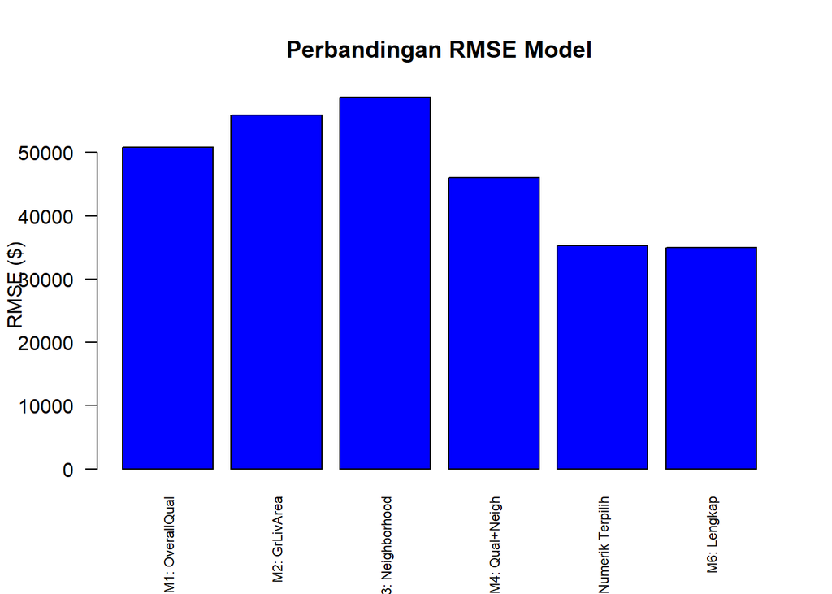

**Interpretasi** Grafik menunjukkan bahwa nilai RMSE menurun seiring bertambahnya variabel prediktor dalam model, artinya terdapat peningkatan akurasi prediksi. Model 6 memiliki RMSE terendah (~ 34.900), sehingga memberikan prediksi paling akurat, sedangkan Model 3 memiliki RMSE tertinggi (~ 58.700), yang menunjukkan performa paling rendah. Secara keseluruhan, penambahan kombinasi variabel fisik rumah dan lokasi mampu mengurangi kesalahan prediksi secara signifikan dibandingkan model sederhana yang hanya menggunakan satu variabel.

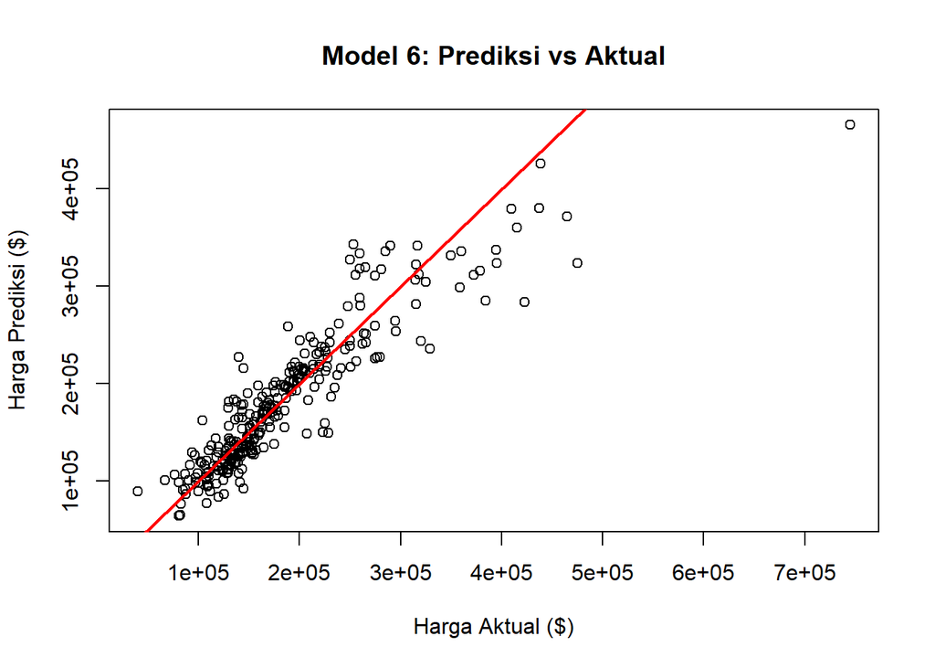

## Perbandingan R² dan Adjusted R²

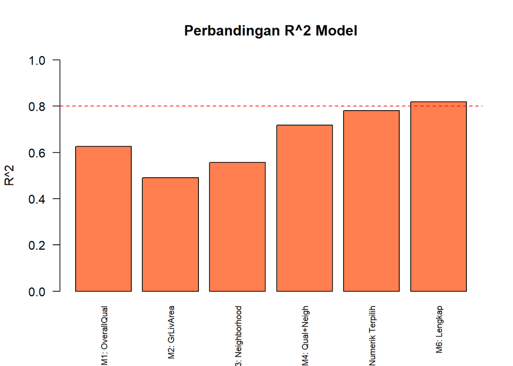

**Interpretasi** Grafik menunjukkan bahwa nilai R^2 meningkat seiring bertambahnya variabel prediktor dalam model. Model 6 memiliki performa terbaik dengan R²^2 = 0,818, yang berarti mampu menjelaskan sekitar 81,8% variasi harga rumah, sedangkan Model 1 dengan variabel OverallQual saja sudah cukup kuat dengan R^2 = 0,626. Secara keseluruhan, kombinasi faktor kualitas, ukuran, usia, fasilitas, dan lokasi rumah menghasilkan peningkatan akurasi prediksi yang signifikan dibandingkan penggunaan satu variabel saja.

### Cek Multikolinearitas (VIF)

Karena terdapat banyak prediktor, perlu dicek apakah ada prediktor yang saling berkorelasi. Sesuai materi: VIF 1 = tidak ada masalah, 1-5 = ringan, >5 = tinggi. Model 1,2,3 tidak perlu dicek karena hanya memiliki 1 prediktor.

```
##                  GVIF Df GVIF^(1/(2*Df))
## OverallQual  2.080308  1        1.442327
## Neighborhood 2.080308 24        1.015378
```

**Kesimpulan** Model 4 memiliki nilai VIF antara 1 - 1,4. Hal ini berarti terdapat multikolinearitas antara kedua variabel namun masih sangat ringan dan model sudah cukup baik.

```
## OverallQual   GrLivArea TotalBsmtSF   YearBuilt  GarageCars   ExterQual
##    3.607785    1.935776    1.703436    2.212228    1.845729    2.960965
## KitchenQual    BsmtQual  Fireplaces
##    2.419385    2.172627    1.337265
```

**Kesimpulan** Model 5 memiliki nilai VIF antara 1,2 - 3,6. Hal ini berarti ada multikolinearitas namun masih ringan dan model dapat dikatakan sudah cukup baik.

```
##                   GVIF Df GVIF^(1/(2*Df))
## OverallQual   3.668358  1        1.915296
## GrLivArea     2.272456  1        1.507467
## Neighborhood 19.163766 24        1.063453
## ExterQual     2.895200  1        1.701529
## YearBuilt     5.414088  1        2.326819
## GarageCars    3.060605  1        1.749458
## MSSubClass    1.438201  1        1.199250
## GarageType    4.574667  6        1.135089
```

## Kesimpulan

Dari seluruh proses analisis yang dilakukan, mulai dari pembersihan data, eksplorasi variabel, hingga pemodelan, dapat disimpulkan bahwa harga rumah (SalePrice) dipengaruhi oleh banyak faktor, terutama kualitas bangunan, ukuran rumah, kondisi fisik, dan lokasi.

Dari hasil seleksi variabel, ditemukan bahwa beberapa variabel memiliki hubungan yang cukup kuat dengan harga rumah, seperti OverallQual, GrLivArea, Neighborhood, ExterQual, YearBuilt, GarageCars, MSSubClass, dan GarageType. Variabel-variabel ini dipilih berdasarkan hasil uji statistik yang menunjukkan hubungan yang signifikan dengan harga rumah.

Dalam proses pemodelan, dibangun enam model regresi untuk dibandingkan. Hasilnya menunjukkan bahwa semakin lengkap dan relevan variabel yang digunakan, performa model juga semakin baik. Hal ini terlihat dari meningkatnya nilai R^2 serta menurunnya RMSE pada model-model yang lebih kompleks.